# Представљање и тумачење скупа података „AutoScout24 Car Listings“

Семинарски рад из предмета Увод у науку о подацима

Богдан Богићевић, 28/2022

Марко Младеновић, 72/2022

08.11.2026.

# 1 Увод

Предмет анализе је скуп података *AutoScout24 Car Listings*, преузет са платформе Kaggle. Садржи огласе возила са европског тржишта, прикупљене са портала AutoScout24, једног од највећих европских онлајн тржишта аутомобила. Снимак скупа направљен је 08.11.2025. године.

**Извор:** `https://www.kaggle.com/datasets/clkmuhammed/autoscout24-car-listings-dataset`

Сваки ред представља један оглас. Колоне обухватају техничке карактеристике возила, податке о стању и историји, листе опреме, као и податке о продавцу и локацији оглашавања.

**Циљ рада** је процена цене половног путничког возила на основу његових карактеристика. Циљна променљива је `price`, изражена у еврима, па је реч о **регресионом проблему**.

Рад је организован тако да сваки корак анализе садржи мотивацију за примењени поступак, код у програмском језику R, резултат извршења и тумачење добијених резултата.

## 1.1 Структура рада

Поглавље 2 описује припрему података. Поглавље 3 даје опис нумеричких и категоријских обележја. Поглавља 4 и 5 посвећена су нетипичним и недостајућим вредностима. Поглавље 6 обухвата биваријантну анализу, а поглавље 7 анализу нумеричких података, креирање нових обележја и моделирање. Ограничења рада наведена су у поглављу 8, а закључци у поглављу 9.

## 1.2 Организација кода

Анализа је подељена на нумерисане R скрипте које се извршавају редом. Свака снима међурезултат у `.rds` формату, који следећа учитава. Датотека `00_funkcije.R` садржи заједничке константе и помоћне функције и учитава се на почетку сваке скрипте.

```
skripte/
  00_funkcije.R          заједничке константе и помоћне функције
  00a_recnik_podataka.R  дијагностика скупа и израда речника података
  01_priprema.R          припрема              -> auta_cisto.rds
  02_opis_numericki.R    опис нумеричких обележја
  03_opis_kategorijski.R опис категоријских обележја
  04_netipicne.R         нетипичне вредности   -> auta_bez_anomalija.rds
  05_nedostajuce.R       недостајуће вредности -> auta_imputirano.rds
  06_bivarijantna.R      биваријантна анализа
  07_feature_eng.R       нова обележја         -> auta_feature_eng.rds
  08_modeli_lin.R        линеарна регресија    -> auta_model.rds
  09_modeli_reg.R        регуларизација
```

Нумерација прати поглавља извештаја, а не редослед извршавања: скрипта `06` ради над обележјима која настају тек у `07`, па се покреће после ње.

Све границе и прагови дефинисани су као константе на једном месту, у `00_funkcije.R`, па се у коду нигде не понављају укуцане вредности:

```r
DATUM_SNIMKA <- as.Date("2025-11-08")  # НЕ Sys.Date() - резултати морају
                                       # бити поновљиви
CENA_MIN     <- 1000
CENA_MAX     <- 250000
STAROST_MAX  <- 25
KM_GOD_MAX   <- 60000
ALFA         <- 0.05                   # праг значајности кроз цео рад
SEME         <- 2026                   # set.seed пре сваке случајне операције
MIN_PAROVA   <- 100                    # минимум опсервација за корелацију
```

Највећи део табела у извештају рачуна се при самом превођењу документа, директно из снимљених међурезултата. Изузетак су резултати моделирања у одељку 7.2: пун модел има преко 360 коефицијената над 75.000 опсервација, па се његове процене не понављају при сваком превођењу него се преносе из извршења скрипте `08_modeli_lin.R`. Такве табеле су означене у наслову.

## 1.3 Коришћени пакети

```r
library(tidyverse)   # обрада и визуализација података
library(naniar)      # анализа недостајућих вредности
library(glmnet)      # гребена и ласо регресија
library(car)         # дијагностика регресије, VIF
library(knitr)       # генерисање извештаја
library(here)        # путање независне од радног директоријума
```

# 2 Припрема података

Скуп у изворном облику има 118 382 редова и 75 колона. Припрема је спроведена у скрипти `01_priprema.R`.

Важна напомена о редоследу: припрема **не импутира** недостајуће вредности. Оне остају нетакнуте и обрађују се у поглављу 5. Циљ ове фазе је да подаци буду структурно исправни, а не потпуни.

## 2.1 Речник података

Пре било какве обраде, за свих 75 колона израђен је речник података са значењем, типом, уделом недостајућих вредности и донетом одлуком. Речник је служио као заједнички референтни документ и спречио да се иста колона различито третира у различитим фазама рада.

Део одлука предложен је аутоматски, помоћу хеуристика у скрипти `00a_recnik_podataka.R` — на пример, колона без варијације или колона са великим бројем јединствених вредности. Хеуристика је, међутим, само предлог: коначну одлуку је за сваку колону доносио тим.

Расподела одлука у речнику података

| Одлука | Број колона |
| --- | --- |
| ZADRZATI | 32 |
| IZBACITI | 31 |
| PARSIRATI | 6 |
| SPOJITI | 4 |
| AGREGIRATI | 1 |
| IZVEDENA | 1 |

Речник садржи и редове за обележја која су тек требала да буду изведена, па укупан број редова превазилази број изворних колона. У табели су приказане само одлуке о колонама изворног скупа.

> Пример у коме је хеуристика погрешила: колона `zip` (поштански број) препозната је као „број са јединицом“, јер холандски поштански бројеви имају облик `"8801 PN"`. Реч је, наравно, о локацијској ознаци. Аутоматско препознавање види **облик** вредности, али не и њено значење.

## 2.2 Парсирање текстуалних колона

Две колоне садрже бројеве записане као текст. Колона `weight_kg` нема нумеричког парњака, па се парсира; колона `mileage_km` га има (`mileage_km_raw`), па се уклања.

```r
# "1,945 kg" -> 1945   (зарез је сепаратор хиљада, не децимални)
broj_sa_jedinicom <- function(x) {
  x %>% str_remove_all("[^0-9.,]") %>% str_remove_all(",") %>% as.numeric()
}

# "4,8" -> 4.8         (зарез јесте децимални сепаратор)
decimalni_zarez <- function(x) as.numeric(str_replace(x, ",", "."))

df <- df %>%
  mutate(masa_kg    = broj_sa_jedinicom(weight_kg),
         ocena_prod = decimalni_zarez(ratings_average))
```

Парсирање је исправно, али је открило грешку у изворним подацима: добијене вредности масе кретале су се од 1 kg до 93.000 kg. Најлакши серијски аутомобили имају око 600 kg, а најтежи путнички око 3.500 kg.

```r
sirovi %>%
  mutate(masa = broj_sa_jedinicom(weight_kg)) %>%
  filter(masa < 500 | masa > 4000) %>%
  count(weight_kg, sort = TRUE) %>%
  head(8) %>%
  kable(caption = "Неисправне вредности масе у изворним подацима")
```

Неисправне вредности масе у изворним подацима

| weight_kg | n |
| --- | --- |
| 1 kg | 9 |
| 253 kg | 8 |
| 4,640 kg | 6 |
| 2 kg | 3 |
| 257 kg | 2 |
| 267 kg | 2 |
| 119 kg | 1 |
| 13,950 kg | 1 |

Такве вредности преведене су у `NA`. Редови нису брисани, јер је маса само један од већег броја предиктора — брисање целог огласа због једне погрешне ћелије значило би губитак свих осталих исправних података о том возилу.

## 2.3 Разграничење електричних возила од хибрида

Овај корак претходи третману нултих вредности и за њега је пресудан.

Колона `fuel_category` разликује потпуно електрична возила од хибридних. За потребе анализе уведена су **два различита индикатора**:

```r
GORIVA_EL       <- c("Electric", "Electric/Gasoline", "Electric/Diesel")
GORIVA_CISTO_EL <- "Electric"

df <- df %>%
  mutate(
    je_elektricno = fuel_category %in% GORIVA_EL,       # обележје за модел
    je_cisto_el   = fuel_category %in% GORIVA_CISTO_EL  # за третман нула
  )
```

Возила са електричним погоном

| Индикатор | Број возила |
| --- | --- |
| je_elektricno (укључујући хибриде) | 28502 |
| je_cisto_el (искључиво електрична) | 7524 |

Разлика између та два појма није формалност. **Хибрид има мотор са унутрашњим сагоревањем**, дакле има цилиндре и запремину мотора. Да је за третман нула коришћен шири индикатор, око 4.100 нултих вредности код хибрида било би погрешно задржано као исправан податак.

## 2.4 Третман нултих вредности

Нула није увек недостајућа вредност. Код искључиво електричног возила нула цилиндара, нулта запремина мотора, нулта емисија CO₂ и нулта потрошња горива представљају **исправне вредности**. Код свих осталих возила иста вредност је прикривена недостајућа вредност.

```r
nula_u_na <- function(x, zadrzi_nulu) {
  if_else(x == 0 & !zadrzi_nulu, NA_real_, x)
}

df <- df %>%
  mutate(
    cylinders           = nula_u_na(cylinders,           je_cisto_el),
    cylinders_volume_cc = nula_u_na(cylinders_volume_cc, je_cisto_el),
    co2                 = nula_u_na(co2,                 je_cisto_el),
    potrosnja           = nula_u_na(potrosnja,           je_cisto_el),
    gears               = if_else(gears == 0, NA_real_, gears)  # никад исправна
  )
```

Третман нултих вредности (вредности из извршења скрипте)

| Колона | Нула пре | Нула после | Преведено у NA |
| --- | --- | --- | --- |
| cylinders | 722 | 265 | 457 |
| cylinders_volume_cc | 921 | 921 | 0 |
| co2 | 8239 | 6160 | 2079 |
| potrosnja | 1619 | 25 | 1594 |
| gears | 129 | 0 | 129 |

Два запажања из ове табеле:

- Колона `cylinders_volume_cc` остала је **непромењена**. То значи да све њене нулте вредности припадају искључиво електричним возилима, што је исправно.
- Истовремено, број нула у `cylinders` је 265, а у `cylinders_volume_cc` чак
  921. Код дела електричних возила запремина мотора уписана је као нула, док је број цилиндара остављен празан. Иста чињеница — одсуство мотора са унутрашњим сагоревањем — записана је на два различита начина, што је пример недоследности у изворним подацима.

## 2.5 Спајање комплементарних колона

Потрошња горива и емисија CO₂ записане су по два стандарда: старијем NEDC и новијем WLTP. Провера преклапања показује да возило има попуњену једну или другу вредност, али готово никада обе.

```r
sirovi %>%
  summarise(
    `само NEDC` = sum(!is.na(fuel_cons_comb_l100_km) &
                        is.na(fuel_cons_comb_l100_wltp_km)),
    `само WLTP` = sum(is.na(fuel_cons_comb_l100_km) &
                        !is.na(fuel_cons_comb_l100_wltp_km)),
    `оба`       = sum(!is.na(fuel_cons_comb_l100_km) &
                        !is.na(fuel_cons_comb_l100_wltp_km)),
    `ниједан`   = sum(is.na(fuel_cons_comb_l100_km) &
                        is.na(fuel_cons_comb_l100_wltp_km))
  ) %>%
  kable(caption = "Преклапање NEDC и WLTP вредности за потрошњу горива")
```

Преклапање NEDC и WLTP вредности за потрошњу горива

| само NEDC | само WLTP | оба | ниједан |
| --- | --- | --- | --- |
| 41784 | 30210 | 60 | 46328 |

Спајањем удео недостајућих вредности пада са 64,7% на приближно 39%.

Спајање, међутим, није безазлено. **WLTP је строжи циклус мерења** и даје систематски више вредности за исто возило. Просто обједињавање унело би мерну пристрасност зависну од стандарда по коме је возило мерено. Зато се уз обједињену вредност задржава и индикатор порекла вредности, преко кога модел може да апсорбује систематску разлику.

```r
df <- df %>%
  mutate(
    potrosnja = coalesce(fuel_cons_comb_l100_wltp_km, fuel_cons_comb_l100_km),
    co2       = coalesce(co2_emission_grper_wltp_km,  co2_emission_grper_km),
    standard  = case_when(
      !is.na(fuel_cons_comb_l100_wltp_km) ~ "WLTP",
      !is.na(fuel_cons_comb_l100_km)      ~ "NEDC",
      TRUE                                ~ "непознат"
    )
  )
```

Прерачунавање једног стандарда у други није спроведено: свега 60 возила има обе вредности потрошње и 15 обе вредности емисије, што је премало за поуздану процену фактора прерачунавања.

Претпоставка да стандард зависи искључиво од године регистрације **није се потврдила** — NEDC вредности јављају се и 2025. године, а WLTP већ 2010. Који ће стандард бити уписан зависи и од продавца и од извора податка.

## 2.6 Извођење обележја `poreklo`

Колона `original_market` има 61,5% недостајућих вредности. Провера је показала да попуњеност изразито варира по земљама оглашавања, што је случај описан у поглављу 5.

Када јесте попуњена, вредност се у већини случајева поклапа са земљом огласа, па `NA` **не значи** „домаће возило“. Због тога `NA` остаје као засебан ниво, што је код категоријских променљивих легитиман поступак.

```r
ZEMLJE <- c(DE = "Germany", IT = "Italy", NL = "Netherlands", BE = "Belgium",
            ES = "Spain", AT = "Austria", FR = "France", LU = "Luxembourg")

df <- df %>%
  mutate(poreklo = case_when(
    is.na(original_market)                  ~ "nepoznato",
    original_market == ZEMLJE[country_code] ~ "domace",
    TRUE                                    ~ "strano"
  ))
```

Цена по пореклу возила

| poreklo | n | медијана цене | медијана старости |
| --- | --- | --- | --- |
| nepoznato | 56828 | 33900 | 5.77 |
| domace | 34631 | 34250 | 5.10 |
| strano | 2259 | 59950 | 4.52 |

> **Упозорење при тумачењу.** Ниво „страно“ има осетно вишу медијану цене, али то **није** узрочни ефекат увоза. Реч је о **селекционој пристрасности**: увоз возила преко границе исплати се само код скупљих примерака, јер разлика у цени мора да покрије трошкове транспорта и регистрације. Групе се, дакле, разликују по томе ко у њих улази, а не по третману који су примиле.

## 2.7 Уклањање колона

Колоне су уклоњене из шест разлога, наведених по важности.

### 2.7.1 Цурење информације из циљне променљиве

```r
cor(sirovi$price, sirovi$price_net, use = "complete.obs")
```

```
## [1] 0.9993408
```

Колона `price_net` је цена без ПДВ-а, дакле **изведеница циљне променљиве**, а не независна карактеристика возила. Измерена корелација потврђује аритметичку везу `price_net = price / (1 + стопа ПДВ-а)`.

Задржавање такве колоне представља **цурење информације** (*data leakage*). Модел би остварио коефицијент детерминације близак јединици, али би научио искључиво начин обрачуна пореза; сви остали предиктори постали би безначајни јер не би имали шта да објасне. У стварној примени модел би био неупотребљив: у тренутку процене цене непознатог возила његова нето цена није позната, а када би била, ни модел не би био потребан.

Из истог разлога уклоњена је и `price_vat_rate`.

### 2.7.2 Колоне без варијације

```r
sirovi %>%
  summarise(across(everything(), ~ n_distinct(.x, na.rm = TRUE))) %>%
  pivot_longer(everything(), names_to = "Колона", values_to = "Нивоа") %>%
  filter(Нивоа <= 1) %>%
  kable(caption = "Колоне без варијације")
```

Колоне без варијације

| Колона | Нивоа |
| --- | --- |
| price_currency | 1 |
| fuel_cons_city_l100_km | 0 |
| fuel_cons_highway_l100_km | 0 |
| has_warranty | 0 |
| warranty | 0 |

Променљива чија је варијанса нула не може објаснити варијацију циљне променљиве.

### 2.7.3 Дуплиране колоне

```r
cor(sirovi$power_kw, sirovi$power_hp, use = "complete.obs")
```

```
## [1] 0.999998
```

Колоне `power_kw` и `power_hp` су иста величина у две мерне јединице. Њихова истовремена употреба дала би сингуларну матрицу предиктора, па је задржана само `power_hp`. Слично, `mileage_km` је текстуална верзија нумеричке колоне `mileage_km_raw`, а `seller_is_dealer` дуплира богатију колону `seller_type`.

> Важно разграничење за поглавље 7: корелација `power_kw` и `power_hp` износи **тачно 1**, што значи да је реч о истој информацији двапут — једна колона је сувишна. Насупрот томе, `power_hp` и `cylinders_volume_cc` имају корелацију око 0,75; оне јесу повезане, али свака носи и сопствену информацију (турбо мотор од 2 литре даје 400 KS, атмосферски од 3 литре око 250 KS). Њихова повезаност се зато не решава уклањањем, него дијагностиком преко VIF-а и регуларизацијом.

### 2.7.4 Идентификатори и слободан текст

Уклоњене су колоне `id`, `vin`, `german_hsn_tsn`, `zip`, `street`, `seller_company_name`, `city` и `body_color_original`. Све имају велики број јединствених вредности, па их модел не би уопштавао него запамтио, што води у прекомерно прилагођавање.

Колоне `description`, `model_version`, `model` и четири `equipment_*` колоне **задржане су у овој фази**, иако су означене за уклањање — потребне су за креирање нових обележја у поглављу 7, и уклањају се тек после тога.

### 2.7.5 Колона `production_year`

Назив колоне наводи на закључак да је реч о години производње возила. Провера је показала супротно.

```r
sirovi %>%
  filter(!is.na(production_year),
         lubridate::year(registration_date) - production_year >= 5) %>%
  select(make, model, production_year, registration_date,
         mileage_km_raw, price) %>%
  head(6) %>%
  kable(caption = "Возила са великом разликом између године и датума регистрације")
```

Возила са великом разликом између године и датума регистрације

| make | model | production_year | registration_date | mileage_km_raw | price |
| --- | --- | --- | --- | --- | --- |
| Suzuki | Vitara | 2020 | 2025-09-01 | 1345 | 28490 |
| Mercedes-Benz | GLA 180 | 2016 | 2025-03-01 | 3794 | 36590 |
| Audi | Q8 | 2020 | 2025-04-01 | 1 | 95000 |
| Mercedes-Benz | GLA 200 | 2016 | 2025-03-01 | 5947 | 40290 |
| Porsche | 992 | 2019 | 2024-03-01 | 14994 | 135900 |
| Audi | Q8 | 2020 | 2025-04-01 | 1 | 95000 |

Mercedes GLA 200 са годином 2016, регистрован 2025. и са неколико хиљада пређених километара, не може бити возило старо девет година. Вредност одговара **години почетка производње модела или генерације**, а не конкретног примерка. Исто важи за Porsche 992 (генерација из 2019) и Audi Q8 (2020).

Разлог за уклањање, дакле, није висок удео недостајућих вредности, него чињеница да колона не представља оно што њен назив сугерише.

### 2.7.6 Колона `primary_fuel`

```r
sirovi %>%
  count(fuel_category, primary_fuel, sort = TRUE) %>%
  head(8) %>%
  kable(caption = "Однос колона `fuel_category` и `primary_fuel`")
```

Однос колона `fuel_category` и `primary_fuel`

| fuel_category | primary_fuel | n |
| --- | --- | --- |
| Gasoline | NA | 26439 |
| Diesel | Diesel | 18753 |
| Diesel | NA | 18247 |
| Gasoline | Regular/Benzine 91 | 9905 |
| Electric/Gasoline | NA | 9656 |
| Gasoline | Super 95 | 8406 |
| Electric | Electricity | 5812 |
| Gasoline | Super E10 95 | 3799 |

Вредности типа `"Super 95"` и `"Regular/Benzine 91"` представљају препоручену октанску вредност горива, дакле подкатегорију онога што `fuel_category` већ носи. Уз 55,4% недостајућих вредности, колона је уклоњена.

## 2.8 Дефиниција популације

Анализа не обухвата цео скуп. Популација је сужена на **половна путничка возила** са ценом у одређеном опсегу. Сва три услова одговарају на питање *ко улази у анализу*, за разлику од следећег корака, који уклања неисправне записе.

**Само половна возила.** Цена новог возила формира се по ценовнику произвођача и зависи од опреме и попуста, док се цена половног формира амортизацијом. Модел који истовремено учи оба процеса не описује добро ниједан.

**Само путничка возила.** Колона `vehicle_type` садржи и 81 теретно возило, чија цена зависи од носивости и запремине товарног простора.

**Цена између 1.000 и 250.000 EUR.** Испод доње и изнад горње границе налазе се огласи који припадају другим сегментима тржишта.

```r
niske <- sirovi %>%
  filter(price < CENA_MIN, price > 1) %>%
  mutate(starost_god = as.numeric(DATUM_SNIMKA - registration_date) / 365.25)

tibble(
  Мера = c("Огласа са ценом од 1 EUR",
           "Огласа са ценом од 2 до 999 EUR",
           "Од тога старијих од 5 година",
           "Медијана старости (године)",
           "Медијана километраже (km)",
           "Возила са преко 200.000 km"),
    Вредност = c(
    format(sum(sirovi$price <= 1, na.rm = TRUE), big.mark = "."),
    format(nrow(niske), big.mark = "."),
    format(sum(niske$starost_god >= 5, na.rm = TRUE), big.mark = "."),
    format(round(median(niske$starost_god, na.rm = TRUE), 1), decimal.mark = ","),
    format(median(niske$mileage_km_raw, na.rm = TRUE), big.mark = "."),
    format(sum(niske$mileage_km_raw > 200000, na.rm = TRUE), big.mark = ".")
  )
) %>% kable(caption = "Профил огласа испод доње границе")
```

Профил огласа испод доње границе

| Мера | Вредност |
| --- | --- |
| Огласа са ценом од 1 EUR | 8 |
| Огласа са ценом од 2 до 999 EUR | 260 |
| Од тога старијих од 5 година | 258 |
| Медијана старости (године) | 21,6 |
| Медијана километраже (km) | 250.000 |
| Возила са преко 200.000 km | 183 |

Испод доње границе налази се 8 огласа са ценом од 1 EUR и 260 огласа са ценом између 2 и 999 EUR. Прва група су очигледне замене за неунету вредност. Друга је, супротно очекивању, скоро у целини састављена од **веома старих возила велике километраже**: медијана старости износи 21,6 година, медијана километраже 250.000 km, а 70,4% их је прешло преко 200.000 km. Млађих од пет година има свега 2.

### 2.8.1 Проверена и одбачена претпоставка

Пре него што је граница постављена, проверено је једно друго објашњење. Портали са огласима приказују и лизинг понуде, код којих је истакнут износ **месечне рате** уместо цене возила. Да је неки од тих огласа ушао у скуп, у колони `price` нашле би се помешане две различите величине — исти структурни проблем на који смо наишли код потрошње горива, где су вредности по стандардима WLTP и NEDC биле уписане у исту колону.

Претпоставка се проверава преко два обрасца. Рате лизинга формирају се на износима који се завршавају цифром 9, и нуде се на новим или готово новим возилима.

Завршна цифра цене испод доње границе

| Завршна цифра | Број огласа |
| --- | --- |
| 0 | 187 |
| 9 | 62 |
| 5 | 6 |
| 4 | 3 |

Ниједан од два обрасца се не појављује. Цифра 0 јавља се готово три пута чешће од цифре 9, а најчешће вредности — 999, 900, 500, 600, 750 — одговарају уобичајеном заокруживању код јефтиних возила. Уз то, само 2 возила од 260 су млађа од пет година, а једно од њих има преко 270.000 пређених километара. Претпоставка се одбацује.

### 2.8.2 Шта границе заправо раде

Изнад горње границе налазе се колекционарска и хиперспортска возила, код којих цену формира реткост, а не километража и старост.

> Обе границе издвајају **другу популацију**, а не неисправне податке — изузетак је осам огласа са ценом од 1 EUR. Испод доње границе цену више не одређује стање возила него вредност његових делова; изнад горње одређује је реткост примерка. Између те две границе налази се сегмент у коме цену формирају особине возила, а то је сегмент који се моделира.

Ово разграничење важно је за тумачење резултата. Модел не тврди ништа о возилу старом двадесет година са 250.000 km, нити о Ferrariju од пола милиона евра — не зато што су ти подаци погрешни, него зато што тамо делују механизми које обележја из овог скупа не мере.

```r
auta_opseg <- df %>%
  filter(is_used      == TRUE,
         vehicle_type == "Car",
         price        >= CENA_MIN,
         price        <= CENA_MAX) %>%
  mutate(
    starost_god  = as.numeric(DATUM_SNIMKA - registration_date) / 365.25,
    km_po_godini = mileage_km_raw / pmax(starost_god, 0.5),
    log_price    = log(price)
  )
```

Деоба `pmax(starost_god, 0.5)` спречава да возило регистровано пре месец дана добије астрономску вредност километраже по години. То је стандардна замка код изведених количника.

## 2.9 Уклањање неисправних записа

На дефинисану популацију примењена су четири филтера, од којих сваки уклања записе са утврђеном грешком.

Филтери и број уклоњених записа

[output not shown]

### 2.9.1 Граница старости

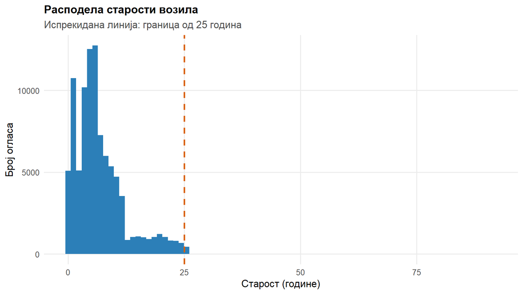

Расподела старости возила

```r
auta_opseg %>%
  filter(starost_god >= 0) %>%
  ggplot(aes(starost_god)) +
  geom_histogram(bins = 80, fill = BOJA_1) +
  geom_vline(xintercept = STAROST_MAX, color = BOJA_2,
             linetype = "dashed", linewidth = .8) +
  labs(title = "Расподела старости возила",
       subtitle = paste0("Испрекидана линија: граница од ", STAROST_MAX,
                         " година"),
       x = "Старост (године)", y = "Број огласа") +
  tema_rad()
```

Граница од 25 година није произвољно одабрана. Хистограм показује густу масу до те вредности и нагли прелом после ње, а не постепено опадање. Иза границе остају само разуђени појединачни примерци, до 91 године старости. Налаз се поклапа са тржишном поделом, јер је у Европи 25–30 година уобичајен праг за статус олдтајмера. Код олдтајмера цена **расте** са старошћу, супротно од осталих возила, па би њихово задржавање значило да обележје `starost_god` носи два супротна ефекта истовремено.

Врх расподеле налази се око четири до пет година старости, што одговара возилима која се враћају са лизинга.

### 2.9.2 Неисправан датум регистрације

Изведено обележје `km_po_godini` дало је вредности и преко милион километара годишње. Провера појединачних записа открила је узрок.

```r
auta_opseg %>%
  filter(km_po_godini > KM_GOD_MAX) %>%
  select(make, model, registration_date, mileage_km_raw, km_po_godini, price) %>%
  arrange(desc(km_po_godini)) %>%
  head(6) %>%
  kable(caption = "Записи са немогућом километражом по години", digits = 0)
```

Записи са немогућом километражом по години

| make | model | registration_date | mileage_km_raw | km_po_godini | price |
| --- | --- | --- | --- | --- | --- |
| BYD | Atto 3 | 2023-08-01 | 2424696 | 1067012 | 26990 |
| Mercedes-Benz | E 270 | 2025-09-01 | 367000 | 734000 | 2600 |
| Alfa Romeo | Giulietta | 2026-11-01 | 310000 | 620000 | 3490 |
| Mercedes-Benz | CLK 280 | 2025-09-01 | 290000 | 580000 | 6000 |
| Mercedes-Benz | C 200 | 2025-09-01 | 260000 | 520000 | 6000 |
| Mercedes-Benz | GL 400 | 2025-07-01 | 230000 | 460000 | 19000 |

Mercedes E 270, модел чија је производња завршена средином двехиљадитих, не може бити регистрован 2025. године са 367.000 пређених километара. Реч је највероватније о датуму поновне регистрације или увоза.

> Налаз показује да изведена обележја нису само припрема за моделирање, већ и **средство контроле квалитета изворних података**. Грешка у колони `registration_date` није била уочљива директно, него тек преко количника изведеног из ње.

### 2.9.3 Осетљивост границе

Граница од 60.000 km годишње постављена је на горњи домет интензивне службене употребе: то је 164 пређена километра сваког дана у години, без изузетка. Пошто је реч о одлуци аутора, треба проверити колико резултат зависи од ње.

Записи изнад границе, по појасевима километраже по години

| Појас | Број записа |
| --- | --- |
| 60.000 – 80.000 | 57 |
| 80.000 – 100.000 | 11 |
| 100.000 – 200.000 | 22 |
| преко 200.000 | 28 |

Отворено остаје питање најнижег појаса. Записи између 60.000 и 80.000 km годишње **могли би бити стварни**, јер службена возила на дугим релацијама достижу такву употребу. Њих има 57, што је 0.06% скупа. Подизање границе на 80.000 променило би скуп за тај износ, дакле без икаквог утицаја на процене модела. Граница је зато задржана на нижој, конзервативнијој вредности.

### 2.9.4 Зашто се записи уклањају, а не означавају

У поглављу 4 немогуће вредности се **не бришу** него преводе у `NA`, уз образложење да је грешка у једној ћелији док остатак записа остаје употребљив. Овде се поступа другачије, и разлика је намерна.

Обележје `km_po_godini` је **количник** километраже и старости. Када количник испадне немогућ, зна се да је једна од две улазне вредности погрешна, али не и која. Обе су међу најјачим предикторима цене — корелација километраже са логаритмом цене износи −0,66, а старости −0,55. Запис код кога је једна од те две вредности нетачна, а не зна се која, не може се ни поправити ни употребити.

Зато овај услов припада **дефиницији популације** из претходног одељка, а не обради нетипичних вредности. Он не каже да је податак редак, него да запис не описује возило чија се цена може моделирати расположивим обележјима.

## 2.10 Контроле исправности

Скрипта се завршава низом провера. Уколико било која не прође, извршавање се прекида — боље него да грешка неприметно уђе у моделе.

```r
stopifnot(
  nrow(auta) > 90000,
  all(auta$price >= CENA_MIN & auta$price <= CENA_MAX),
  all(auta$starost_god >= 0 & auta$starost_god <= STAROST_MAX),
  all(auta$mileage_km_raw > 0),
  !any(c("price_net", "price_vat_rate") %in% names(auta)),   # цурење
  all(is.finite(auta$log_price)),
  # нула цилиндара сме да остане само код искључиво електричних возила
  all(auta$fuel_category[which(auta$cylinders == 0)] == "Electric"),
  all(is.na(auta$masa_kg) | (auta$masa_kg >= 500 & auta$masa_kg <= 4000))
)
```

## 2.11 Резиме припреме

Сужавање скупа по корацима

| Корак | Редова | Изгубљено |
| --- | --- | --- |
| Цео скуп | 118 382 | NA |
| Само половна путничка возила | 95 603 | 22779 |
| Цена у опсегу | 94 376 | 1227 |
| Уклоњени неисправни записи | 93 718 | 658 |

Радни скуп има 93 718 редова и 48 колона. Укупан губитак износи око 21%, од чега највећи део отпада на свесно сужавање популације, а мање од 1% на уклањање неисправних записа.

# 3 Опис података

Радни скуп има 18 нумеричких колона. Детаљно се описује осам, одабраних по два критеријума: да су доменски релевантни за формирање цене и да имају разумну попуњеност. Изостављене су колоне које описују **продавца**, а не возило (`ratings_*`), као и обележја са врло малим бројем нивоа (`nr_doors`, `nr_seats`).

## 3.1 Циљна променљива

Дескриптивна статистика цене (EUR), радни скуп

| Статистика | Вредност |
| --- | --- |
| Минимум | 1 000 |
| 1. квартил | 21 890 |
| Медијана | 34 400 |
| Средња вредност | 49 754 |
| 3. квартил | 64 990 |
| Максимум | 250 000 |
| Стандардна девијација | 43 304 |
| Коефицијент асиметрије | 1.82 |

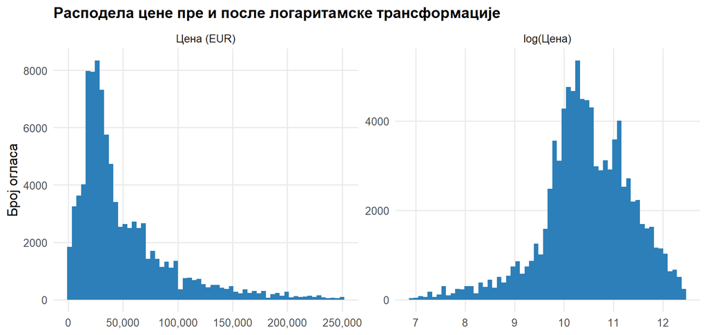

Расподела цене пре и после логаритамске трансформације

```r
auta %>%
  select(price, log_price) %>%
  pivot_longer(everything()) %>%
  mutate(name = factor(name, levels = c("price", "log_price"),
                       labels = c("Цена (EUR)", "log(Цена)"))) %>%
  ggplot(aes(value)) +
  geom_histogram(bins = 60, fill = BOJA_1) +
  facet_wrap(~ name, scales = "free") +
  scale_x_continuous(labels = scales::comma) +
  labs(title = "Расподела цене пре и после логаритамске трансформације",
       x = NULL, y = "Број огласа") +
  tema_rad()
```

Расподела цене је изразито десно закошена, са коефицијентом асиметрије 1.82, што је очекивано за цене на тржишту.

Логаритамска трансформација смањује апсолутну асиметрију више од три пута, на -0.59. Резултат, међутим, **није савршено симетрична расподела** — трансформација благо прекоригује, па је добијена расподела лако **лево** закошена. Узрок је доња граница цене од 1.000 EUR, која одсеца леви реп расподеле. Преостало одступање је прихватљиво.

Модели ће се градити над `log(price)` из три разлога: задовољава се претпоставка о приближно нормалним резидуалима, смањује се утицај екстремних вредности, и коефицијенти постају читљиви као **процентуална** промена цене — што одговара стварности, јер старење умањује цену за проценат, а не за фиксни износ у еврима.

### 3.1.1 Провера нормалности

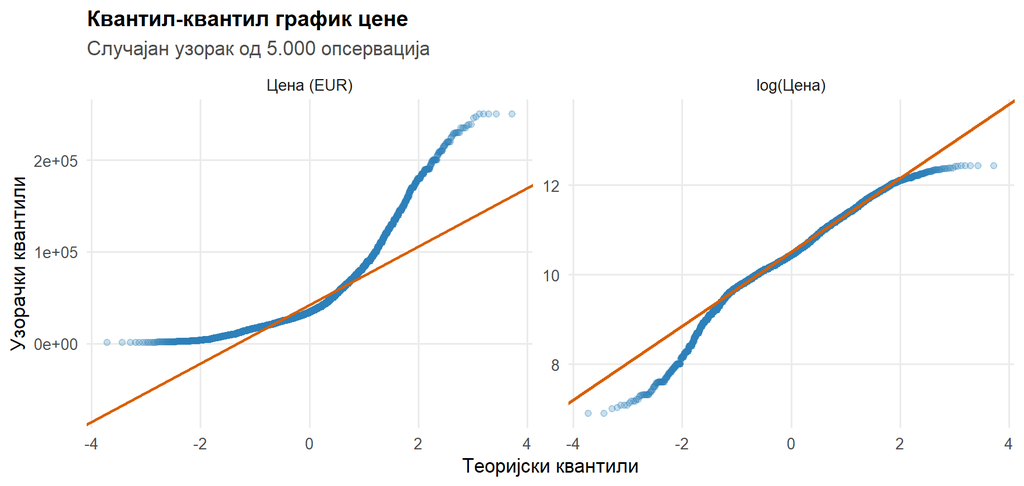

Квантил-квантил график цене

```r
set.seed(SEME)
uzorak <- sample(nrow(auta), 5000)

auta[uzorak, ] %>%
  select(price, log_price) %>%
  pivot_longer(everything()) %>%
  mutate(name = factor(name, levels = c("price", "log_price"),
                       labels = c("Цена (EUR)", "log(Цена)"))) %>%
  ggplot(aes(sample = value)) +
  stat_qq(alpha = .25, color = BOJA_1) +
  stat_qq_line(color = BOJA_2, linewidth = .8) +
  facet_wrap(~ name, scales = "free_y") +
  labs(title = "Квантил-квантил график цене",
       subtitle = "Случајан узорак од 5.000 опсервација",
       x = "Теоријски квантили", y = "Узорачки квантили") +
  tema_rad()
```

> **Зашто није коришћен тест нормалности.** Шапиро-Вилков тест ради на највише 5.000 опсервација, а радни скуп их има преко 90.000. На узорку те величине сваки тест нормалности одбацује нулту хипотезу због одступања која су практично занемарљива — статистичка значајност не значи и практичну значајност. Нормалност се зато процењује **графички**, преко квантил-квантил графика, и нумерички преко коефицијента асиметрије.

## 3.2 Описи нумеричких обележја

Дескриптивна статистика нумеричких обележја

| Назив | Јединица | n | NA | Минимум | Медијана | Ср. вред. | Максимум | Ст. дев. | Асиметрија |
| --- | --- | --- | --- | --- | --- | --- | --- | --- | --- |
| Цена | EUR | 93718 | 0 | 1000.00 | 34400.00 | 49753.71 | 250000.00 | 43304.47 | 1.82 |
| Пређена километража | km | 93718 | 0 | 1.00 | 76600.00 | 86440.66 | 858890.00 | 67881.00 | 1.10 |
| Старост возила | године | 93718 | 0 | 0.02 | 5.44 | 6.66 | 24.94 | 5.24 | 1.33 |
| Километража по години | km/год | 93718 | 0 | 0.04 | 13207.04 | 14192.03 | 59927.12 | 8318.33 | 0.93 |
| Снага мотора | KS | 92527 | 1191 | 1.00 | 247.00 | 276.36 | 11033.00 | 146.56 | 6.35 |
| Запремина мотора | cm³ | 84915 | 8803 | 0.00 | 1998.00 | 2425.02 | 29930.00 | 876.33 | 1.42 |
| Маса возила | kg | 74440 | 19278 | 720.00 | 1800.00 | 1840.50 | 3800.00 | 410.04 | 0.45 |
| Комбинована потрошња | l/100 km | 55854 | 37864 | 0.00 | 6.10 | 6.99 | 7500.00 | 32.03 | 229.21 |

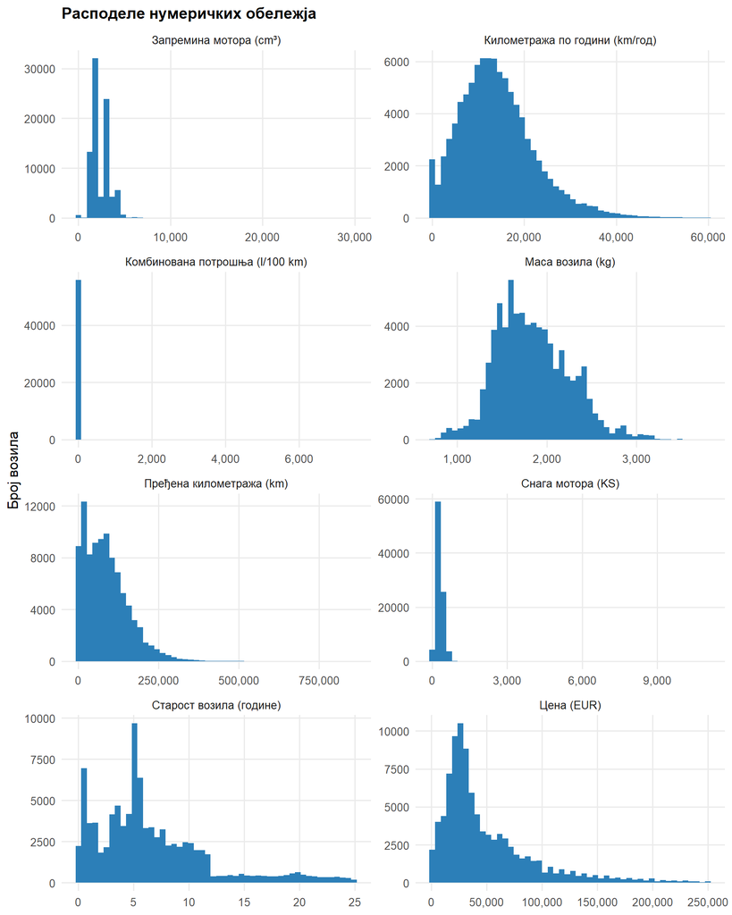

Расподеле нумеричких обележја

```r
dugacki <- auta %>%
  select(all_of(OBELEZJA$kolona)) %>%
  pivot_longer(everything(), names_to = "kolona", values_to = "vrednost") %>%
  filter(!is.na(vrednost)) %>%
  left_join(OBELEZJA, by = "kolona") %>%
  mutate(oznaka = paste0(naziv, " (", jedinica, ")"))

ggplot(dugacki, aes(vrednost)) +
  geom_histogram(bins = 50, fill = BOJA_1) +
  facet_wrap(~ oznaka, scales = "free", ncol = 2) +
  scale_x_continuous(labels = scales::comma) +
  labs(title = "Расподеле нумеричких обележја", x = NULL, y = "Број возила") +
  tema_rad()
```

Из табеле и графика издвајају се три запажања.

**Маса возила је једино приближно симетрично обележје**, са коефицијентом асиметрије око 0,45. Сва остала су десно закошена, што је уобичајено за величине које имају природну доњу границу, а немају горњу.

**Снага мотора и потрошња имају неочекивано високе максимуме** — 11 033 KS и 7 500 l/100 km. Реч је о грешкама у подацима, које се обрађују у поглављу 4.

**Километража по години има медијану од 13 207 km**, што одговара просечној годишњој километражи европског возача. То потврђује да је изведено обележје смислено конструисано.

### 3.2.1 Структурна особеност: запремина мотора

```r
auta %>%
  filter(cylinders_volume_cc == 0) %>%
  count(fuel_category, name = "Број возила") %>%
  kable(caption = "Возила са нултом запремином мотора")
```

Возила са нултом запремином мотора

| fuel_category | Број возила |
| --- | --- |
| Electric | 460 |

Расподела запремине мотора има изражен шиљак у нули. Провера показује да све такве вредности припадају **искључиво електричним возилима**, код којих је нула исправан податак, а не грешка.

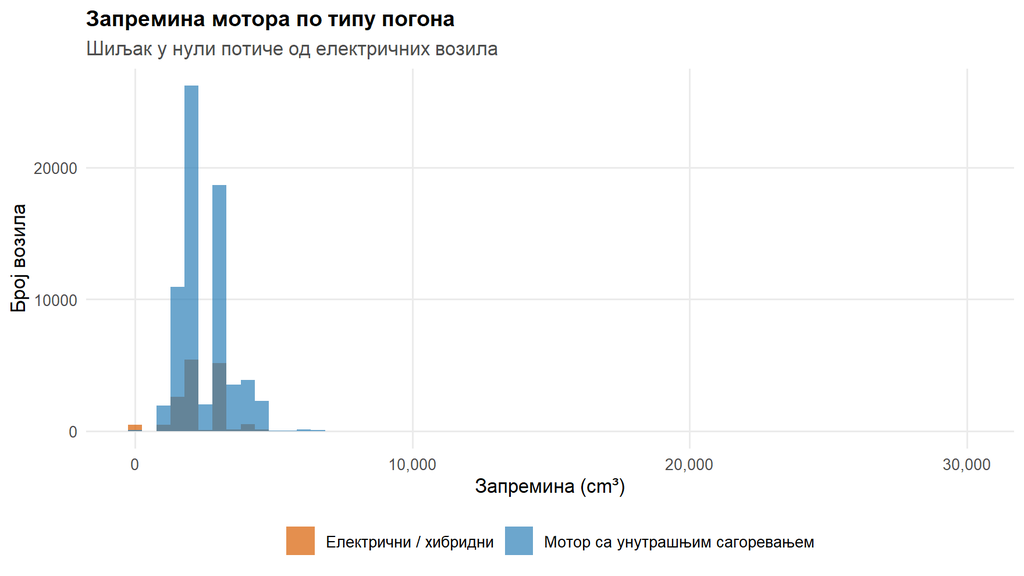

Запремина мотора по типу погона

```r
auta %>%
  filter(!is.na(cylinders_volume_cc)) %>%
  mutate(pogon = if_else(je_elektricno, "Електрични / хибридни",
                         "Мотор са унутрашњим сагоревањем")) %>%
  ggplot(aes(cylinders_volume_cc, fill = pogon)) +
  geom_histogram(bins = 60, position = "identity", alpha = .7) +
  scale_fill_manual(values = c(BOJA_2, BOJA_1)) +
  scale_x_continuous(labels = scales::comma) +
  labs(title = "Запремина мотора по типу погона",
       subtitle = "Шиљак у нули потиче од електричних возила",
       x = "Запремина (cm³)", y = "Број возила", fill = NULL) +
  tema_rad()
```

## 3.3 Везе са циљном променљивом

Корелације са log(цена) у скупу пре обраде нетипичних вредности

| Обележје | r | Број парова |
| --- | --- | --- |
| Снага мотора | 0.693 | 92527 |
| Пређена километража | -0.660 | 93718 |
| Старост возила | -0.554 | 93718 |
| Запремина мотора | 0.521 | 84915 |
| Маса возила | 0.422 | 74440 |
| Километража по години | -0.169 | 93718 |
| Комбинована потрошња | 0.023 | 55854 |

Три обележја показују јасну и доменски очекивану везу: снага мотора позитивну, а километража и старост негативну.

Корелација потрошње са ценом износи свега 0,023, што је неочекивано — потрошња би морала бити повезана са ценом. Узрок је једна екстремна вредност, о чему се детаљно говори у поглављу 4.

> Уз сваки коефицијент наведен је и **број парова**. Корелација израчуната на малом броју заједничких опсервација је безвредна: у овом скупу постојао је пар обележја са коефицијентом 0,968 израчунатим на свега **шест** редова. Зато помоћна функција `korelacije_pouzdane()` одбацује сваки пар са мање од 100 заједничких опсервација.

Међусобне корелације предиктора (|r| ≥ 0,5)

| kolona_1 | kolona_2 | r | n_parova |
| --- | --- | --- | --- |
| power_hp | cylinders_volume_cc | 0.749 | 84198 |
| power_hp | log_price | 0.693 | 92527 |
| mileage_km_raw | log_price | -0.660 | 93718 |
| mileage_km_raw | starost_god | 0.655 | 93718 |
| starost_god | log_price | -0.554 | 93718 |
| cylinders_volume_cc | log_price | 0.521 | 84915 |

Уочене јаке везе међу предикторима — снага мотора са запремином, старост са километражом — најављују проблем **мултиколинеарности**. Он се анализира преко VIF-а у поглављу 7 и представља главни аргумент за примену регуларизације.

## 3.4 Описи категоријских обележја

Категоријска обележја описују припадност возила одређеној групи, као што су произвођач, тип каросерије, врста горива или мењача. За разлику од нумеричких обележја, код њих су основне мере описне статистике **фреквенција** (број појављивања категорије), **релативна фреквенција** (процентуални удео) и **модус** (најчешћа категорија).

Анализа је спроведена над скупом `auta_cisto`, који садржи **93.718 огласа** након почетне припреме података, а пре обраде нетипичних и недостајућих вредности. Циљ је да се прикажу структура скупа, неравномерна заступљеност категорија и обим недостајућих података, без испитивања повезаности са ценом (то је предмет биваријантне анализе).

### 3.4.1 Општи преглед категоријских обележја

У радном скупу налази се **14 категоријских обележја**. За свако су израчунати број различитих категорија, модус, удео модуса и број и проценат недостајућих вредности. При одређивању модуса вредности `NA` нису сматране категоријом. **Удео модуса** рачунат је међу огласима са познатом вредношћу тог обележја, а **проценат недостајућих** у односу на свих 93.718 огласа.

Преглед 14 категоријских обележја пре импутације

| Обележје | Број категорија | Модус | Удео модуса (%) | Број NA | Недостаје (%) |
| --- | --- | --- | --- | --- | --- |
| make | 25 | BMW | 38.9 | 0 | 0.00 |
| body_color | 14 | Black | 34.5 | 11.113 | 11.86 |
| upholstery_color | 11 | Black | 73.8 | 29.005 | 30.95 |
| envir_standard | 11 | Euro 6 | 37.7 | 33.298 | 35.53 |
| body_type | 9 | Off-Road/Pick-up | 38.0 | 0 | 0.00 |
| fuel_category | 9 | Gasoline | 45.7 | 52 | 0.06 |
| country_code | 8 | DE | 34.3 | 12 | 0.01 |
| upholstery | 6 | Full leather | 56.9 | 24.193 | 25.81 |
| transmission | 3 | Automatic | 79.6 | 731 | 0.78 |
| drive_train | 3 | 4WD | 55.4 | 22.422 | 23.92 |
| standard | 3 | NEDC | 42.2 | 0 | 0.00 |
| poreklo | 3 | nepoznato | 60.6 | 0 | 0.00 |
| paint_type | 2 | Metallic | 76.2 | 22.052 | 23.53 |
| seller_type | 2 | Dealer | 79.4 | 12 | 0.01 |

Број категорија се креће од 2 (`paint_type`, `seller_type`) до 25 (`make`). Код `make` и `body_type` нема недостајућих вредности, док су највећи удели недостајућих присутни код `envir_standard` (35,5%), `upholstery_color` (31,0%), `upholstery` (25,8%), `drive_train` (23,9%) и `paint_type` (23,5%). Ови проценти су важни за каснију обраду недостајућих вредности, која је образложена у поглављу 5.

### 3.4.2 Расподеле најзначајнијих обележја

За детаљнији приказ изабрани су произвођач, тип каросерије, врста горива и тип мењача. Ова обележја имају јасно значење и погодна су за графичко поређење фреквенција. Табеле категорија добијене су помоћном функцијом `opis_kategorijski()` из `00_funkcije.R`, а графикони су направљени у `03_opis_kategorijski.R` и сачувани функцијом `sacuvaj_grafik()`.

```r
# Пример табеле апсолутних, релативних и кумулативних фреквенција.
opis_kategorijski(auta, "transmission")
```

#### 3.4.2.1 Произвођач (`make`)

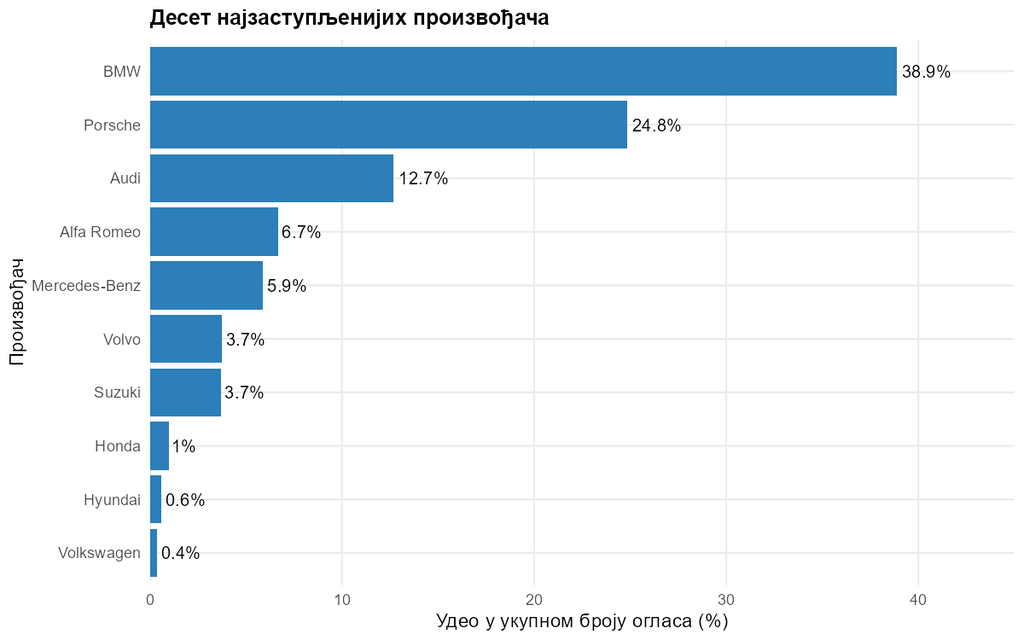

Десет најзаступљенијих произвођача у скупу огласа

Расподела произвођача је изразито неуједначена: **BMW** се јавља у 36.433 огласа (38,9%), **Porsche** у 23.284 (24,8%), а **Audi** у 11.897 (12,7%). Ова три произвођача заједно чине **76,4%** скупа. Иако обележје има 25 категорија, знатно мањи број огласа припада осталим произвођачима.

Оваква заступљеност значи да резултати каснијих модела могу бити поузданији за чешће произвођаче него за ретко заступљене. Расподела представља овај конкретан скуп огласа и не мора одговарати структури целокупног европског тржишта половних возила.

#### 3.4.2.2 Тип каросерије (`body_type`)

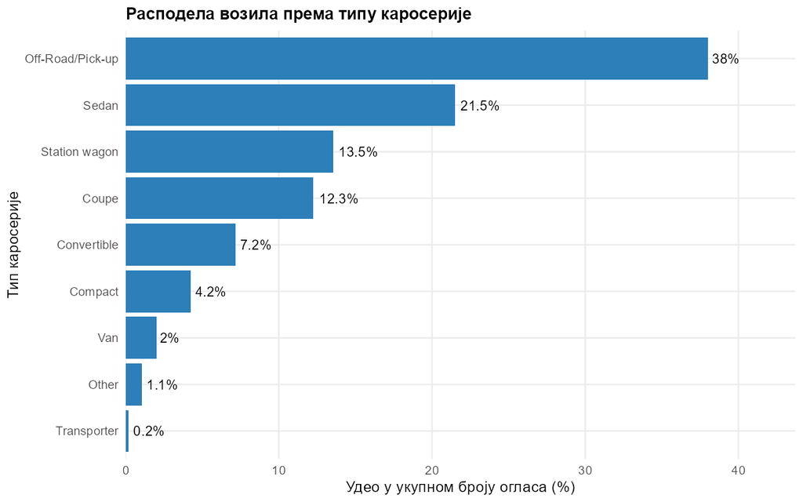

Расподела огласа према типу каросерије

Највише огласа припада категорији **Off-road/Pick-up** (35.624, односно 38%), а затим **Sedan** (21,5%) и **Station wagon** (13,5%). Ове три категорије обухватају укупно **73%** огласа. Преосталих шест типова каросерије заступљено је у мањем обиму. За ово обележје нема недостајућих вредности.

#### 3.4.2.3 Врста горива (`fuel_category`)

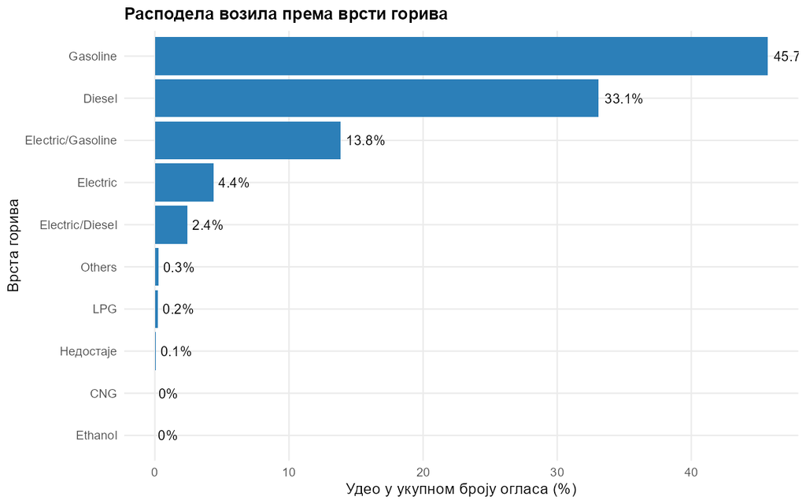

Расподела огласа према врсти горива

Најзаступљенија су возила на **бензин** (42.824, тј. 45,7%) и **дизел** (31.012, тј. 33,1%), која заједно чине **78,8%** скупа. Категорије `Electric/Gasoline` (13,8%) и `Electric/Diesel` (2,4%) односе се на комбиновани електрични и моторни погон, док искључиво електрична возила чине **4,4%** огласа. За 52 огласа врста горива није позната.

#### 3.4.2.4 Тип мењача (`transmission`)

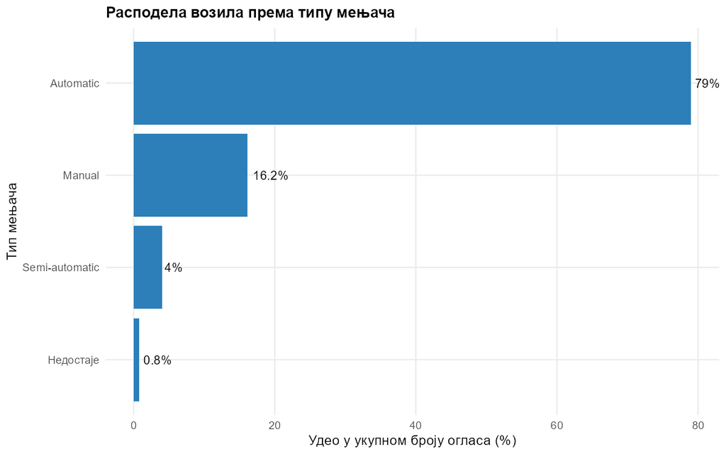

Расподела огласа према типу мењача

У скупу убедљиво доминирају возила са **аутоматским мењачем**: 74.061 оглас, односно **79%**. Ручни мењач се јавља у 16,2% огласа, а **полуаутоматски** у 4,0%. За 0,78% огласа недостаје тип мењача. Ова изражена неравномерност важна је при каснијем тумачењу односа типа мењача и других карактеристика возила.

### 3.4.3 Остала категоријска обележја

**Тип продавца (`seller_type`).** Дилери су заступљени у 74.434 огласа (**79,4%**), док је 19.272 огласа (**20,6%**) постављено од стране приватних продаваца. Податак недостаје за само 12 огласа.

**Врста погона (`drive_train`).** Највећи удео у укупном скупу има погон на сва четири точка (`4WD`) са **42,2%** огласа. Задњи погон чини **17,7%**, а предњи **16,2%**. Ипак, код **23,9%** огласа погон није наведен. Зато наведене проценте треба тумачити као уделе у свим огласима, а не само међу возилима са познатом врстом погона.

**Еколошки стандард (`envir_standard`).** Ово обележје има највећи удео недостајућих вредности, **35,5%**. Међу појединачним наведеним вредностима најчешћи је `Euro 6`, присутан у **24,3% свих огласа**, а следе `Euro 6d-TEMP` (12,0%) и `Euro 6d` (11,4%). Ове ознаке су у подацима засебне категорије и не треба их мешати са недостајућим вредностима.

И друга обележја, попут боје каросерије, боје и материјала пресвлака, земље оглашавања и типа боје, обухваћена су општом табелом. За њих нису прављени додатни графикони како се исти вид анализе не би непотребно понављао.

### 3.4.4 Закључак описне анализе

Категоријска обележја показују **неравномерне расподеле**: неколико произвођача, аутоматски мењачи и поједини типови каросерије заступљени су далеко чешће од осталих категорија. Истовремено, квалитет попуњености није једнак: док су произвођач и тип каросерије потпуни, код еколошког стандарда и појединих података о опреми недостаје знатан број вредности.

Ови налази пружају основу за даљу обраду података и указују на потребу за опрезом при тумачењу резултата за ретко заступљене категорије. У овом поглављу нису извођени закључци о утицају категоријских обележја на цену: такве везе испитују се у биваријантној анализи и моделима у наредним поглављима.

# 4 Анализа нетипичних вредности

Централна идеја овог поглавља јесте разграничење **реткoг** од **немогућег**. Статистичка правила откривају шта је ретко, али не и шта је немогуће. Porsche 911 са ценом од 200.000 EUR јесте статистички нетипичан, али је потпуно исправан податак и део тржишта које се моделира. Мотор од 11.033 KS не постоји ни у једном серијском возилу.

## 4.1 Униваријантна анализа

### 4.1.1 Правило интерквартилног распона

Вредност се сматра нетипичном ако излази ван граница $Q_1 - 1{,}5 \cdot IQR$ и $Q_3 + 1{,}5 \cdot IQR$.

Правило интерквартилног распона (k = 1,5)

| Обележје | Доња граница | Горња граница | Испод | Изнад | % скупа |
| --- | --- | --- | --- | --- | --- |
| Цена | -42760.0 | 129640.0 | 0 | 6256 | 6.68 |
| Пређена километража | -112139.4 | 267283.6 | 0 | 1615 | 1.72 |
| Старост возила | -5.4 | 17.6 | 0 | 5942 | 6.34 |
| Километража по години | -7091.4 | 34133.9 | 0 | 2325 | 2.48 |
| Снага мотора | -150.5 | 677.5 | 0 | 729 | 0.79 |
| Запремина мотора | 430.5 | 4530.5 | 562 | 936 | 1.76 |
| Маса возила | 692.5 | 2952.5 | 0 | 692 | 0.93 |
| Комбинована потрошња | -0.5 | 13.9 | 0 | 960 | 1.72 |

> **Ограничење правила.** Оно је изведено под претпоставком приближно симетричне расподеле. Пошто су готово сва обележја у овом скупу десно закошена, правило означава вредности **само са десне стране** — код цене чак 6,68% скупа. То не значи да је толики део података погрешан, него да правило није прилагођено облику расподеле.

### 4.1.2 Стандардизоване вредности

Стандардизоване вредности

| Обележје | \|z\| > 3 | \|z\| > 5 | макс \|z\| |
| --- | --- | --- | --- |
| Цена | 2233 | 0 | 4.6 |
| Пређена километража | 943 | 63 | 11.4 |
| Старост возила | 1683 | 0 | 3.5 |
| Километража по години | 1006 | 45 | 5.5 |
| Снага мотора | 373 | 12 | 73.4 |
| Запремина мотора | 263 | 5 | 31.4 |
| Маса возила | 395 | 0 | 4.8 |
| Комбинована потрошња | 21 | 10 | 233.9 |

> **Ефекат маскирања, потврђен бројевима.** z-вредност се рачуна преко средње вредности и стандардне девијације, а обе су осетљиве на саме нетипичне вредности. Код потрошње је то драматично: једна вредност од 7.500 l/100 km подигла је стандардну девијацију на око 32, па је праг $|z| > 3$ постао приближно 103 l/100 km. Правило је зато означило свега **21** вредност, иако их је ван доменског опсега чак **301**. Десетине погрешних вредности између 35 и 103 прошле су неприметно — једна екстремна вредност сакрила је све остале. Због тога се z-вредност користи само као допунска мера.

## 4.2 Доменске границе

Доменске границе и њихово образложење

| Обележје | Доња | Горња | Образложење |
| --- | --- | --- | --- |
| Снага мотора (KS) | 20 | 1500 | Bugatti Chiron, плафон серијске производње |
| Запремина мотора (cm³) | 550 | 8500 | од smart forTwo (599) до V10 мотора |
| Емисија CO₂ (g/km) | 1 | 600 | хемија сагоревања: ~2,3 kg CO₂ по литру бензина |
| Потрошња (l/100 km) | 1 | 35 | доња граница НЕ важи за прикључне хибриде |
| Километража (km) | 1 | 600000 | врло висока, али могућа вредност |

Горња граница емисије CO₂ изведена је из хемије сагоревања, а не процењена одока: сагоревањем једног литра бензина настаје око 2,3 kg угљен-диоксида, а литра дизела око 2,6 kg. Уз потрошњу ограничену на 35 l/100 km, физички могућа горња вредност износи приближно 600 g/km.

Постављање граница захтевало је проверу појединачних случајева, јер је прва, строжа верзија уклањала исправне податке. Три случаја заслужују опис.

**Porsche Taycan са 1.033 KS је стваран.** Четири возила у скупу имају тачно ту вредност, старост испод године дана и цену између 196.000 и 241.000 EUR. Реч је о моделу Taycan Turbo GT, чија максимална снага уз *launch control* износи 760 kW односно 1.034 PS. Прва верзија границе била је постављена на 1.000 KS и уклањала је те исправне податке.

**smart forTwo са 599 cm³ је стваран.** Прва генерација тог модела имала је трoцилиндрични мотор те запремине. Ред у скупу има 3 цилиндра, 54 KS и цену од 1.999 EUR, што се у потпуности слаже.

**Прикључни хибриди легитимно имају потрошњу испод 1 l/100 km.**

```r
auta %>%
  filter(potrosnja < 1) %>%
  count(fuel_category, name = "Број возила", sort = TRUE) %>%
  kable(caption = "Возила са потрошњом испод 1 l/100 km")
```

Возила са потрошњом испод 1 l/100 km

| fuel_category | Број возила |
| --- | --- |
| Electric/Gasoline | 140 |
| Electric/Diesel | 102 |
| Electric | 7 |
| Gasoline | 4 |
| Diesel | 3 |
| Others | 1 |

Међу њима доминирају `Electric/Gasoline` и `Electric/Diesel`. WLTP циклус за прикључне хибриде урачунава део вожње на електрични погон, па су вредности између 0,5 и 2 l/100 km уобичајене. Првобитна доња граница од 1 l/100 km уклањала је **242 исправне вредности**. Чиста возила са мотором са унутрашњим сагоревањем испод те вредности (4 бензинца, 3 дизелаша и једно „Others“) заиста јесу грешке.

> Поука: доменска граница није формалност него **модел саме стварности**. Лоше постављена граница уништава тачне податке подједнако ефикасно као што добра уклања погрешне.

## 4.3 Примена одлуке

Немогуће вредности преводе се у `NA`, а редови се **не бришу**. Реч је о грешци у једној ћелији, док остале вредности у том реду остају исправне; брисање целог огласа због погрешне снаге мотора значило би губитак исправних података о цени, километражи, старости и опреми. Настале недостајуће вредности обрађују се у поглављу 5.

```r
auta <- auta %>%
  mutate(
    je_hibrid = fuel_category %in% c("Electric/Gasoline", "Electric/Diesel"),

    power_hp = van_domena(power_hp, 20, 1500),

    cylinders_volume_cc = case_when(
      je_cisto_el & cylinders_volume_cc == 0 ~ cylinders_volume_cc,  # исправна нула
      je_cisto_el                            ~ NA_real_,             # нема мотора
      TRUE ~ van_domena(cylinders_volume_cc, 550, 8500)
    ),

    potrosnja = case_when(
      je_cisto_el    ~ NA_real_,      # гориво неприменљиво
      potrosnja > 35 ~ NA_real_,      # горња граница важи за све
      je_hibrid      ~ potrosnja,     # доња НЕ важи за прикључне хибриде
      potrosnja < 1  ~ NA_real_,
      TRUE           ~ potrosnja
    ),

    co2 = case_when(
      je_cisto_el & co2 == 0 ~ co2,   # исправна нула
      je_cisto_el            ~ NA_real_,
      co2 < 1 | co2 > 600    ~ NA_real_,
      TRUE                   ~ co2
    ),

        mileage_km_raw = van_domena(mileage_km_raw, 1, 600000),

    # Сентинел вредности: 99, 127 и 255 нису ретке вредности него
    # ознаке за непопуњено поље у изворном огласу.
    # Комбиновани минибуси (Sprinter и слично) легитимно имају
    # преко 9 седишта, па за њих важи шира граница.
    nr_seats = case_when(
      body_type %in% c("Van", "Transporter") ~ van_domena(nr_seats, 1, 23),
      TRUE                                   ~ van_domena(nr_seats, 1, 9)
    ),

    # Ниједан серијски аутомобил нема преко 10 степени преноса.
    gears = van_domena(gears, 1, 10),

    # Највећи серијски мотор је W16, значи 16 цилиндара.
    cylinders = van_domena(cylinders, 0, 16),

    # Возило са једним вратима не постоји. Шеста врата код теренаца
    # обично значе да је хауба пребројана као врата, али вредност
    # није физички немогућа, па је задржавамо.
    nr_doors = van_domena(nr_doors, 2, 6),

    nr_prev_owners = van_domena(nr_prev_owners, 0, 10)
  ) %>%
  select(-je_hibrid)
```

### 4.3.1 Ефекат поступка

Број уклоњених вредности, асиметрија и корелација са log(цена)

| Обележје | Уклоњено | Асим. пре | Асим. после | r пре | r после |
| --- | --- | --- | --- | --- | --- |
| Снага мотора | 30 | 6.35 | 0.86 | 0.693 | 0.727 |
| Запремина мотора | 216 | 1.42 | 0.67 | 0.521 | 0.531 |
| Емисија CO₂ | 20 | 214.81 | -0.05 | 0.014 | 0.150 |
| Потрошња | 350 | 229.21 | 0.76 | 0.023 | 0.367 |
| Пређена километража | 4 | 1.10 | 1.07 | -0.660 | -0.660 |

Два обележја заслужују посебан осврт, јер показују колико мали број вредности може да поништи информативност целе колоне.

**Потрошња.** Коефицијент асиметрије пада са 229 на приближно 0,8, а корелација са логаритмом цене расте са 0,023 на око 0,37. Једна једина вредност од 7.500 l/100 km држала је ту колону неупотребљивом.

**Емисија CO₂.** Овде је случај још израженији. Уклоњено је свега **пет** вредности изнад 600 g/km, а последице су:

Ефекат уклањања пет немогућих вредности емисије CO₂

| Мера | Пре | После |
| --- | --- | --- |
| Стандардна девијација | 752 | 75,1 |
| Коефицијент асиметрије | 215 | −0,05 |
| Корелација са потрошњом | 0,063 | 0,926 |
| R² регресионог модела за импутацију | 0,004 | 0,876 |

Пирсонов коефицијент корелације рачуна се преко одступања од средње вредности, па га неколико изузетно удаљених тачака може потпуно изобличити. Пре обраде, веза између потрошње горива и емисије CO₂ — која је по хемији сагоревања готово детерминистичка — мерена је као практично непостојећа (0,063). После уклањања пет вредности износи 0,926.

> Налаз показује да **одсуство корелације тамо где је она физички нужна** представља сигнал да су подаци неисправни, а не да веза не постоји. У овом раду је то био повод за проверу која је открила грешку.

Број редова остаје непромењен: 93 718.

## 4.4 Мултиваријантна анализа

Вредност може бити сасвим обична по сваком обележју посебно, а нетипична у **комбинацији**. Возило старо 15 година са 5.000 пређених километара има и уобичајену старост и уобичајену километражу, али не и уобичајену комбинацију.

### 4.4.1 Махаланобисово растојање

Мера удаљености опсервације од центра вишедимензионалне расподеле, која узима у обзир корелације међу обележјима. За приближно нормалну расподелу, квадрат растојања прати хи-квадрат расподелу са $p$ степени слободе, што даје праг.

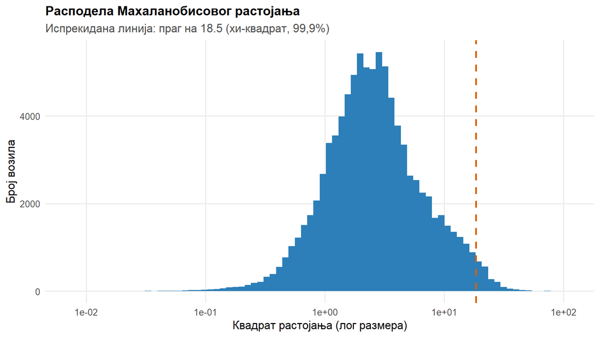

Расподела Махаланобисовог растојања

```r
MV <- c("log_price", "mileage_km_raw", "starost_god", "power_hp")

mv <- auta_bez %>% select(all_of(MV)) %>% drop_na()
d2 <- mahalanobis(mv, center = colMeans(mv), cov = cov(mv))
prag <- qchisq(0.999, df = ncol(mv))

tibble(d2 = d2) %>%
  ggplot(aes(d2)) +
  geom_histogram(bins = 80, fill = BOJA_1) +
  geom_vline(xintercept = prag, color = BOJA_2, linetype = "dashed",
             linewidth = .8) +
  scale_x_log10() +
  labs(title = "Расподела Махаланобисовог растојања",
       subtitle = paste0("Испрекидана линија: праг на ", round(prag, 1),
                         " (хи-квадрат, 99,9%)"),
       x = "Квадрат растојања (лог размера)", y = "Број возила") +
  tema_rad()
```

Прагом од 18.47 означено је 1943 опсервација, односно 2.1% скупа.

Десет најудаљенијих опсервација

| make | model | price | mileage_km_raw | starost_god | power_hp | d2 |
| --- | --- | --- | --- | --- | --- | --- |
| Porsche | 911 | 149911 | 168950 | 19.4 | 1400 | 104.9 |
| Porsche | Boxster | 59990 | 497361 | 8.4 | 300 | 100.0 |
| Honda | Civic | 2900 | 580000 | 12.0 | 120 | 81.0 |
| BMW | 740 | 4995 | 600000 | 24.6 | 245 | 75.5 |
| BMW | M6 | 74999 | 4000 | 9.8 | 1065 | 75.2 |
| BMW | Z4 M | 40999 | 51223 | 22.4 | 999 | 74.5 |
| Alfa Romeo | 159 | 1200 | 290 | 18.9 | 200 | 74.3 |
| Volvo | C70 | 3950 | 578530 | 17.6 | 140 | 73.5 |
| Porsche | 997 | 209990 | 12900 | 16.5 | 1201 | 73.3 |
| Volvo | C70 | 3450 | 563150 | 16.4 | 163 | 67.4 |

> **Налаз који униваријантна анализа није могла да открије.** На листи се налази BMW Z4 M са **999 KS**, иако тај модел фабрички има око 340 KS. Вредност је прошла испод доменске границе од 1.500 KS, али ју је мултиваријантна анализа препознала — јер комбинација те снаге, старости од 22 године и цене од око 41.000 EUR нема смисла. То је најјаснији аргумент зашто обе анализе морају постојати.

На врху листе налазе се и возила са 1.400, 1.201 и 1.065 KS. Она су доменски могућа као тјунована возила, али су сада **најутицајније опсервације у скупу**. Њихов стварни утицај на процене коефицијената мери се Куковим растојањем у поглављу 7.

### 4.4.2 Доменски неуобичајене комбинације

Неуобичајене комбинације обележја

| Комбинација | Број |
| --- | --- |
| Старије од 10 година, мање од 10.000 km | 112 |
| Млађе од 2 године, више од 150.000 km | 0 |
| Снага преко 400 KS, цена испод 10.000 EUR | 24 |
| Цена преко 100.000 EUR, старост преко 15 година | 197 |

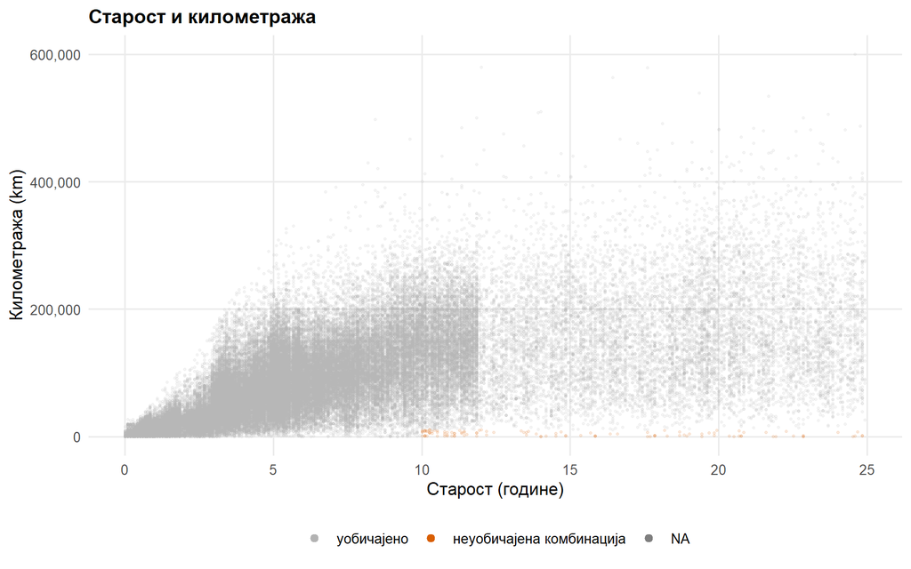

Старост и километража са истакнутим неуобичајеним комбинацијама

```r
auta_bez %>%
  mutate(sumnjivo = starost_god > 10 & mileage_km_raw < 10000) %>%
  ggplot(aes(starost_god, mileage_km_raw, color = sumnjivo)) +
  geom_point(alpha = .1, size = .6) +
  scale_color_manual(values = c(`FALSE` = "grey70", `TRUE` = BOJA_2),
                     labels = c("уобичајено", "неуобичајена комбинација")) +
  scale_y_continuous(labels = scales::comma) +
  labs(title = "Старост и километража",
       x = "Старост (године)", y = "Километража (km)", color = NULL) +
  guides(color = guide_legend(override.aes = list(alpha = 1, size = 2))) +
  tema_rad()
```

Такве комбинације **нису уклоњене**. Оне могу бити исправне — колекционарска возила, примерци из заоставштине или возила која су дуго стајала. Њихов утицај на модел процењује се у поглављу 7.

## 4.5 Резиме поглавља

Три врсте нетипичних вредности и примењени поступци

| Врста нетипичне вредности | Поступак | Пример |
| --- | --- | --- |
| Статистички нетипична, доменски исправна | задржана | Porsche 911 за 200.000 EUR |
| Доменски немогућа | преведена у NA, ред задржан | мотор од 11.033 KS, потрошња 7.500 l/100 km |
| Нетипична само у комбинацији | задржана, процена утицаја у поглављу 7 | возило старо 19 година са 1 km |

# 5 Анализа недостајућих вредности

Главни налаз овог поглавља је да недостајуће вредности у посматраном скупу **нису истородне** и да захтевају различит поступак. Утврђено је пет механизама.

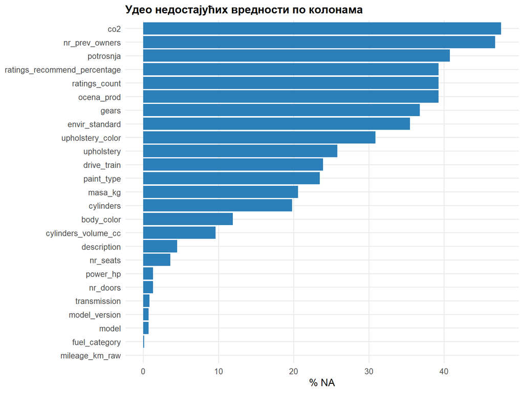

Удео недостајућих вредности по колонама

```r
grafik_na(auta_bez, n = 25)
```

## 5.1 Неприменљиве вредности

Колона `electric_range_km` недостаје у 89,2% случајева зато што возило **није електрично**. Вредност не недостаје — она не постоји. Домет батерије возила са мотором са унутрашњим сагоревањем није непознат податак, већ бесмислен.

Поступак је аналоган третману колоне `Cabin` код путника друге и треће класе на Титанику: такве вредности се не импутирају, већ се из њих изводи индикаторска променљива или се колона уклања.

## 5.2 Стварно недостајуће вредности

Колоне `nr_prev_owners` (46,8% NA), `gears` (36,8%) и `cylinders` (19,8%) недостају зато што продавац није попунио поље. Вредност постоји, само није забележена, па је кандидат за импутацију.

## 5.3 Прикривене недостајуће вредности

Недостајућа вредност не мора бити записана као `NA`. Провера нула по колонама показује да тумачење нуле зависи од контекста.

```r
sirovi %>%
  filter(cylinders == 0 | co2_emission_grper_wltp_km == 0) %>%
  count(fuel_category, sort = TRUE, name = "Број возила") %>%
  kable(caption = "Возила са нултом вредношћу цилиндара или емисије, по врсти горива")
```

Возила са нултом вредношћу цилиндара или емисије, по врсти горива

| fuel_category | Број возила |
| --- | --- |
| Electric | 4659 |
| Electric/Gasoline | 669 |
| Gasoline | 615 |
| Diesel | 223 |
| Electric/Diesel | 38 |
| LPG | 1 |

Нула цилиндара и нулта емисија CO₂ су исправне вредности за **искључиво електрична** возила. За хибриде и возила са мотором са унутрашњим сагоревањем иста вредност представља прикривену недостајућу вредност. Нула се, дакле, тумачи по колони и у контексту друге колоне, никада паушално.

Исто важи за `mileage_km_raw == 0`: половно возило без пређених километара не постоји.

## 5.4 Вредности настале обрадом нетипичних података

Поглавље 4 је немогуће вредности превело у `NA`, чиме је створен нови извор недостајућих података. Те вредности нису „изгубљене“ у изворном скупу — оне су биле уписане, али погрешно. При импутацији се третирају као и свака друга недостајућа вредност.

## 5.5 Недостајање које зависи од друге променљиве (MAR)

Колона `original_market` има 61,5% недостајућих вредности, али попуњеност изразито варира по земљама.

```r
sirovi %>%
  filter(is_used == TRUE) %>%
  mutate(popunjeno = !is.na(original_market)) %>%
  count(country_code, popunjeno) %>%
  pivot_wider(names_from = popunjeno, values_from = n, values_fill = 0,
              names_prefix = "p_") %>%
  mutate(`% попуњено` = round(p_TRUE / (p_TRUE + p_FALSE) * 100, 1)) %>%
  arrange(desc(`% попуњено`)) %>%
  kable(caption = "Попуњеност колоне `original_market` по земљама")
```

Попуњеност колоне `original_market` по земљама

| country_code | p_FALSE | p_TRUE | % попуњено |
| --- | --- | --- | --- |
| ES | 860 | 6368 | 88.1 |
| DE | 13211 | 19607 | 59.7 |
| LU | 469 | 265 | 36.1 |
| BE | 5560 | 3071 | 35.6 |
| IT | 16399 | 5259 | 24.3 |
| AT | 4791 | 1217 | 20.3 |
| NA | 10 | 2 | 16.7 |
| FR | 5439 | 663 | 10.9 |
| NL | 11366 | 1127 | 9.0 |

Распон од приближно 9% у Холандији до 88% у Шпанији показује да вероватноћа недостајања зависи од **друге посматране променљиве**, а не од саме вредности. То одговара механизму **MAR** (*missing at random*).

Исти образац потврђују и друге колоне. Удео недостајућих вредности јасно зависи од типа продавца и од врсте погона.

Удео недостајућих вредности по групама

| Обележје | Груписано по | Група | n | % NA |
| --- | --- | --- | --- | --- |
| gears | fuel_category | Others | 245 | 64.1 |
| gears | fuel_category | Electric | 4105 | 56.3 |
| gears | fuel_category | Diesel | 31012 | 36.9 |
| gears | fuel_category | Gasoline | 42824 | 36.8 |
| gears | fuel_category | Electric/Gasoline | 12953 | 32.3 |
| gears | fuel_category | LPG | 205 | 25.9 |
| gears | fuel_category | Electric/Diesel | 2275 | 21.7 |
| nr_prev_owners | seller_type | NA | 12 | 66.7 |
| nr_prev_owners | seller_type | PrivateSeller | 19272 | 63.4 |
| nr_prev_owners | seller_type | Dealer | 74434 | 42.5 |

Практична последица је двострука. Прво, брисање редова са недостајућом вредношћу дало би **пристрасан узорак**, из кога би систематски нестали приватни продавци, електрична возила и возила из појединих земаља. Друго, импутација мора да **користи управо те групне променљиве**, уместо да рачуна једну заједничку вредност за цео скуп.

## 5.6 Заједнички образац недостајања

```r
auta_bez %>%
  summarise(across(c(ratings_count, ratings_recommend_percentage, ocena_prod),
                   ~ round(mean(is.na(.x)) * 100, 1))) %>%
  pivot_longer(everything(), names_to = "Колона", values_to = "% NA") %>%
  kable(caption = "Три колоне са оценама продавца")
```

Три колоне са оценама продавца

| Колона | % NA |
| --- | --- |
| ratings_count | 39.3 |
| ratings_recommend_percentage | 39.3 |
| ocena_prod | 39.3 |

Три колоне имају **идентичан** удео недостајућих вредности. То није случајност: недостају заједно, јер продавац или има оцене или их нема. Реч је о монотоном обрасцу недостајања, па се те колоне обрађују као једна целина, а не свака засебно.

## 5.7 Импутација

Поступак импутације бира се према **разлогу** недостајања, а не према његовом обиму. Примењена су три различита поступка.

Стратегија импутације по групама обележја

| Група обележја | Поступак | Образложење |
| --- | --- | --- |
| upholstery, upholstery_color, paint_type, body_color, drive_train, envir_standard, transmission, seller_type, country_code | нови ниво „непознато“ | код категоријских обележја одсуство податка је легитимна категорија |
| ocena_prod, ratings_count, ratings_recommend_percentage | индикатор + медијана | монотони образац; одсуство оцена је информација о продавцу |
| masa_kg, cylinders, cylinders_volume_cc, gears, power_hp, nr_seats, nr_doors, mileage_km_raw | медијана по make + model, па по make | техничке карактеристике зависе од модела возила |
| nr_prev_owners | медијана по старосном разреду и типу продавца | број власника расте са старошћу возила |
| co2 | линеарна регресија на потрошњу | емисија је, за дато гориво, готово линеарна функција потрошње |

### 5.7.1 Категоријска обележја: нови ниво

Импутација доминантном вредношћу код обележја са 25–35% недостајућих вредности вештачки би увећала учесталост тог нивоа и смањила варијансу. Увођење нивоа „непознато“ чува информацију да податак није унет, што је код категоријских променљивих уобичајен и оправдан поступак.

Категоријска обележја после увођења новог нивоа

| Колона | Број возила на нивоу „непознато“ |
| --- | --- |
| envir_standard | 33298 |
| upholstery_color | 29005 |
| upholstery | 24193 |
| drive_train | 22422 |
| paint_type | 22052 |
| body_color | 11113 |

### 5.7.2 Техничка обележја: хијерархијска медијана

```r
imputiraj_hijerarhijski <- function(df, kolona) {
  k <- sym(kolona)
  df %>%
    group_by(make, model) %>%       # 1. иста марка И модел
    mutate(!!k := if_else(is.na(!!k), median(!!k, na.rm = TRUE), !!k)) %>%
    group_by(make) %>%              # 2. иста марка
    mutate(!!k := if_else(is.na(!!k), median(!!k, na.rm = TRUE), !!k)) %>%
    ungroup() %>%                   # 3. цео скуп
    mutate(!!k := if_else(is.na(!!k), median(!!k, na.rm = TRUE), !!k))
}
```

Маса возила BMW X5 процењује се из осталих возила истог модела, а тек ако их нема — из осталих BMW возила. Заједничка медијана целог скупа користи се само као последње средство. Тиме се поштује основни принцип импутације: *користити информације других променљивих* уместо једне просечне вредности.

### 5.7.3 Емисија CO₂: регресиона импутација

Емисија угљен-диоксида је, за дато гориво, готово линеарна функција потрошње, јер сагоревањем литра горива настаје приближно константна количина CO₂. То омогућава процену регресијом.

```r
potpuni   <- auta %>% filter(!is.na(co2), !is.na(potrosnja))
model_co2 <- lm(co2 ~ potrosnja + fuel_category, data = potpuni)
```

Модел је процењен на 34.121 возилу и постиже коефицијент детерминације **R² = 0,876**. Њиме је попуњено 43.477 вредности.

> **Ограничење регресионе импутације.** Умeтнуте вредности леже *тачно* на регресионој површи, па немају сопствену варијансу. То вештачки смањује стандардну грешку и чини везу привидно јачом него што јесте. Ограничење је наведено и у градиву предмета, а у овом раду се прати преко индикатора `imput_co2`.

### 5.7.4 Индикатори импутације

Пре сваке импутације креирана је логичка колона `imput_*`, која бележи да је вредност била одсутна. Тиме се проверава да ли **само одсуство податка** носи информацију о цени.

Разлика у медијани цене према томе да ли је вредност импутирана

| Индикатор | n (не) | n (да) | медијана цене (не) | медијана цене (да) | Разлика (%) |
| --- | --- | --- | --- | --- | --- |
| imput_mileage_km_raw | 93714 | 4 | 34400 | 2318 | -93.3 |
| imput_nr_doors | 92531 | 1187 | 34000 | 51900 | 52.6 |
| imput_cylinders_volume_cc | 84699 | 9019 | 33490 | 49865 | 48.9 |
| imput_potrosnja | 55504 | 38214 | 30000 | 41950 | 39.8 |
| imput_nr_seats | 90359 | 3359 | 33990 | 45950 | 35.2 |
| imput_cylinders | 75174 | 18544 | 32890 | 42990 | 30.7 |
| imput_power_hp | 92497 | 1221 | 34000 | 42990 | 26.4 |
| ima_ocene | 36805 | 56913 | 29995 | 37840 | 26.2 |
| imput_masa_kg | 74440 | 19278 | 33000 | 38799 | 17.6 |
| imput_nr_prev_owners | 49839 | 43879 | 36880 | 31970 | -13.3 |
| imput_co2 | 49130 | 44588 | 35400 | 33000 | -6.8 |
| imput_gears | 59256 | 34462 | 33950 | 34980 | 3.0 |

Разлике су изразите, што потврђује да механизам недостајања није случајан. Два индикатора, међутим, захтевају опрез при тумачењу.

Удео импутираних вредности (%) по типу погона

| Електрични погон | imput_cylinders_volume_cc | imput_potrosnja | imput_nr_doors | imput_nr_seats |
| --- | --- | --- | --- | --- |
| FALSE | 6.2 | 33.6 | 1.3 | 3.7 |
| TRUE | 22.9 | 68.2 | 1.1 | 3.3 |

Код обележја `cylinders_volume_cc` и `potrosnja` удео импутираних вредности код електричних возила вишеструко је већи, па ти индикатори у великој мери само понављају податак који колона `fuel_category` већ носи.

Код обележја `nr_doors` и `nr_seats` удео је практично једнак у обе групе, дакле индикатор не мери погон. Провера открива шта мери:

Карактеристике огласа са непопуњеним бројем врата

| Број врата импутиран | n | медијана цене | медијана старости | % Porsche | % салона |
| --- | --- | --- | --- | --- | --- |
| FALSE | 92531 | 34000 | 5.4 | 24.6 | 79.6 |
| TRUE | 1187 | 51900 | 6.4 | 44.4 | 69.3 |

> Налаз илуструје важну разлику: обележје може изгледати снажно када се посматра **само за себе**, а не носити ништа **уз остале предикторе**.

### 5.7.5 Провера ефекта импутације

Расподеле и корелације пре и после импутације

| Обележје | % NA пре | медијана пре | медијана после | ст. дев. пре | ст. дев. после | r пре | r после |
| --- | --- | --- | --- | --- | --- | --- | --- |
| masa_kg | 20.6 | 1800 | 1790.00 | 410.04 | 396.21 | 0.422 | 0.411 |
| power_hp | 1.3 | 249 | 245.00 | 139.66 | 139.49 | 0.727 | 0.726 |
| cylinders_volume_cc | 9.6 | 1998 | 1998.00 | 860.10 | 928.34 | 0.531 | 0.446 |
| potrosnja | 40.8 | 6 | 6.00 | 2.73 | 2.59 | 0.367 | 0.424 |
| co2 | 47.6 | 146 | 146.74 | 75.10 | 67.66 | 0.150 | 0.215 |
| nr_prev_owners | 46.8 | 1 | 1.00 | 0.79 | 0.67 | -0.240 | -0.297 |

Медијане се готово не померају, што значи да импутација није изобличила расподеле. Стандардна девијација код већине обележја **опада**, што је очекивана последица импутације медијаном: уметнуте вредности немају сопствену варијансу. То је позната цена једноставних поступака импутације и наводи се међу ограничењима рада.

Изузетак је `cylinders_volume_cc`, код које стандардна девијација расте, а корелација са ценом пада. Узрок је то што је хијерархијска медијана електричним возилима исправно доделила запремину мотора **нула**. Електрична возила су скупа, а немају мотор са унутрашњим сагоревањем, па се природно слаби позитивна веза између запремине и цене. Налаз указује да то обележје није поуздан предиктор када су у скупу помешани различити типови погона.

### 5.7.6 Преостале недостајуће вредности

Колоне са преосталим недостајућим вредностима

| Колона | % NA |
| --- | --- |
| description | 4.5 |
| model | 0.7 |
| model_version | 0.7 |

Преостале вредности налазе се искључиво у текстуалним колонама (`description`, `model`, `model_version`), које се обрађују у поглављу 7 при креирању нових обележја. Сва нумеричка и категоријска обележја потпуно су попуњена.

# 6 Биваријантна анализа података

Униваријантна анализа из поглавља 3 описала је свако обележје за себе. Биваријантна анализа испитује **везу између два обележја**, и бира поступак према њиховом типу: два категоријска обележја пореде се хи-квадрат тестом независности, два нумеричка коефицијентом корелације, а нумеричко са категоријским поређењем расподела по групама.

> Сви бројеви у овом поглављу рачунати су над **обрађеним** скупом, излазом скрипте `07_feature_eng.R`, дакле после уклањања немогућих вредности и импутације. Зато се разликују од корелација у поглављу 3, које су намерно рачунате над сировим скупом да би се видео утицај нетипичних вредности.

## 6.1 Категоријска наспрам категоријских обележја

### 6.1.1 Врста горива и тип мењача

Пар је изабран зато што врста погона технички условљава избор мењача: електрични погон нема вишестепени мењач у уобичајеном смислу, док су код појединих горива ручни мењачи и даље чести. Из анализе се изостављају возила код којих било које од два обележја има ниво `"непознато"`, јер тај ниво означава одсуство податка а не стварну категорију. У анализи учествује 92.941 возила.

Удео типова мењача унутар сваке врсте горива (%)

| Врста горива | Automatic | Manual | Semi-automatic |
| --- | --- | --- | --- |
| CNG | 58.54 | 17.07 | 24.39 |
| Diesel | 78.29 | 15.37 | 6.34 |
| Electric | 99.70 | 0.27 | 0.02 |
| Electric/Diesel | 85.06 | 0.00 | 14.94 |
| Electric/Gasoline | 91.80 | 4.54 | 3.65 |
| Ethanol | 16.67 | 83.33 | 0.00 |
| Gasoline | 74.97 | 22.69 | 2.34 |
| LPG | 19.90 | 79.60 | 0.50 |
| Others | 91.38 | 8.62 | 0.00 |

Расподела се очигледно разликује: електрична возила готово искључиво имају аутоматски мењач, док код LPG возила доминира ручни. То је за сада само опис — да ли је разлика статистички значајна проверава се тестом.

```r
rez_gm <- hi_kvadrat(biv$fuel_category, biv$transmission,
                     ime_x = "Врста горива", ime_y = "Тип мењача")
```

```
## H0: Обележја Врста горива и Тип мењача су међусобно независна.
## H1: Обележја Врста горива и Тип мењача су међусобно зависна.
```

```
##
##  Pearson's Chi-squared test
##
## data:  tabela
## X-squared = 5971.8, df = 16, p-value < 2.2e-16
##
##
## УПОЗОРЕЊЕ: 4 ћелија има очекивану фреквенцију мању од 5.
## Размотрити агрегацију ретких нивоа или Фишеров тест.
##
## Закључак: p = <2e-16 < 0.05, одбацујемо H0 — обележја су зависна.
```

#### 6.1.1.1 Провера претпоставки

Хи-квадрат тест почива на апроксимацији, која важи само ако су очекиване фреквенције довољно велике. Уобичајено правило тражи да ниједна ћелија нема очекивану фреквенцију мању од 1, и да их највише 20% буде испод 5.

Провера претпоставки хи-квадрат теста

| Мера | Вредност |
| --- | --- |
| Број ћелија | 27.000 |
| Ћелија са очекиваном фреквенцијом < 5 | 4.000 |
| Удео таквих ћелија (%) | 14.810 |
| Најмања очекивана фреквенција | 0.243 |

Удео ћелија испод 5 јесте мањи од 20%, али најмања очекивана фреквенција износи свега 0.243, дакле испод 1. Апроксимација је тиме непоуздана. Узрок су веома ретке категорије горива, па се оне групишу и тест понавља. **Групишу се категорије, а не уклањају опсервације** — ниједно возило не испада из анализе, и `fuel_category` у самом скупу остаје непромењена.

```r
rez_gg <- hi_kvadrat(biv$gorivo_grupa, biv$transmission,
                     ime_x = "Групa горива", ime_y = "Тип мењача")
```

```
## H0: Обележја Групa горива и Тип мењача су међусобно независна.
## H1: Обележја Групa горива и Тип мењача су међусобно зависна.
##
##
##  Pearson's Chi-squared test
##
## data:  tabela
## X-squared = 5811.7, df = 12, p-value < 2.2e-16
##
##
## Закључак: p = <2e-16 < 0.05, одбацујемо H0 — обележја су зависна.
```

После груписања ниједна ћелија нема очекивану фреквенцију испод 5; најмања износи 9.65. Претпоставке су испуњене и закључак о зависности сада стоји.

#### 6.1.1.2 Јачина везе

Хи-квадрат тест одговара само на питање **да ли** веза постоји. При узорку од преко 90.000 возила и најслабија веза излази значајна, па сама p-вредност говори мало. Јачину мери Крамеров коефицијент V, који хи-квадрат статистику нормализује на опсег од 0 до 1.

Јачина везе пре и после груписања ретких категорија

| Табела | Хи-квадрат | Степени слободе | Крамеров V |
| --- | --- | --- | --- |
| пре груписања | 5971.8 | 16 | 0.179 |
| после груписања | 5811.7 | 12 | 0.177 |

Вредност се груписањем померила са 0.179 на 0.177, дакле занемарљиво — што потврђује да груписање није изменило суштину него само поправило услове теста.

Праг за тумачење Крамеровог V **зависи од димензије табеле**, тачније од `df* = min(r−1, c−1)`. Коенове границе за V добијају се дељењем граница за коефицијент *w* кореном из `df*`. Овде је `df* = 2`, па су границе 0,07 / 0,21 / 0,35 за слабу, средњу и јаку везу. Добијених 0.177 налази се између слабе и средње, ближе средњој.

Стандардизовани резидуали (одступање од очекиваног)

| Група горива | Automatic | Manual | Semi-automatic |
| --- | --- | --- | --- |
| CNG/LPG | -20.58 | 22.23 | 0.39 |
| Diesel | -7.24 | -5.41 | 24.90 |
| Electric | 32.46 | -28.27 | -13.31 |
| Electric/Diesel | 6.48 | -21.28 | 26.62 |
| Electric/Gasoline | 36.95 | -38.95 | -2.50 |
| Gasoline | -32.41 | 48.31 | -24.32 |
| Остала горива | 3.78 | -2.42 | -3.18 |

Стандардизовани резидуали показују **где** табела одступа од независности. Под независношћу се понашају приближно као стандардна нормална расподела, па вредности преко 2 по апсолутној вредности означавају значајно одступање. Највеће позитивно одступање имају бензинска возила са ручним мењачем, а највеће негативно хибриди на бензин и струју са ручним мењачем — исти пол, посматран са две стране.

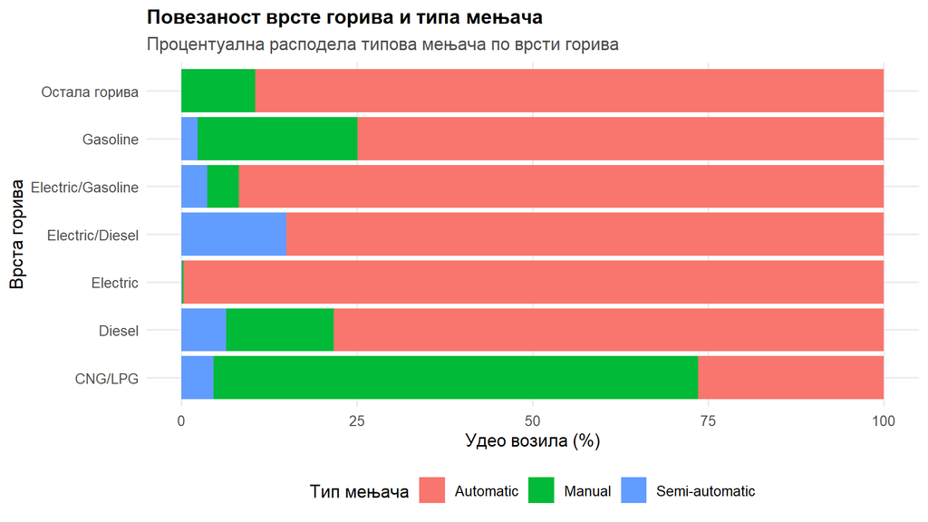

Повезаност врсте горива и типа мењача

```r
biv %>%
  count(gorivo_grupa, transmission) %>%
  group_by(gorivo_grupa) %>%
  mutate(procenat = n / sum(n) * 100) %>%
  ungroup() %>%
  ggplot(aes(x = gorivo_grupa, y = procenat, fill = transmission)) +
  geom_col() +
  coord_flip() +
  labs(title = "Повезаност врсте горива и типа мењача",
       subtitle = "Процентуална расподела типова мењача по врсти горива",
       x = "Врста горива", y = "Удео возила (%)", fill = "Тип мењача") +
  tema_rad()
```

### 6.1.2 Спортски пакет и тип мењача

Други пар повезује једно **изведено** обележје из поглавља 7.1 са техничком карактеристиком возила. Анализа је ограничена на BMW, Audi и Mercedes-Benz, јер је препознавање спортских пакета дефинисано само за те марке; код осталих вредност `FALSE` значи „није дефинисано”, а не „нема пакет”.

Удео типова мењача према присуству спортског пакета (%)

| Спортски пакет | Automatic | Manual | Semi-automatic |
| --- | --- | --- | --- |
| FALSE | 84.69 | 11.83 | 3.48 |
| TRUE | 88.22 | 4.91 | 6.87 |

```r
rez_sp <- hi_kvadrat(sport$ima_sport_paket, sport$transmission,
                     ime_x = "Спортски пакет", ime_y = "Тип мењача")
```

```
## H0: Обележја Спортски пакет и Тип мењача су међусобно независна.
## H1: Обележја Спортски пакет и Тип мењача су међусобно зависна.
##
##
##  Pearson's Chi-squared test
##
## data:  tabela
## X-squared = 793.56, df = 2, p-value < 2.2e-16
##
##
## Закључак: p = <2e-16 < 0.05, одбацујемо H0 — обележја су зависна.
```

Најмања очекивана фреквенција је 628.5, дакле далеко изнад прага — претпоставке су испуњене без икаквог груписања. Крамеров V износи 0.122. Табела је овде димензије 2 × 3, значи `df* = 1`, па су границе 0,1 / 0,3 / 0,5. По тој скали веза је **слаба**, за разлику од претходног пара — иста бројчана вредност не значи исту јачину у табелама различитих димензија.

## 6.2 Нумеричка наспрам нумеричких обележја

Испитују се четири обележја за која се на основу домена очекује најјача веза са ценом. Користе се два коефицијента: **Пирсонов**, који мери линеарну везу, и **Спирманов**, који мери монотону везу и отпорнији је на екстремне вредности јер ради над ранговима.

Корелације са log(цена) на обрађеном скупу

| Обележје | n | Пирсон | Спирман |
| --- | --- | --- | --- |
| Старост возила | 93718 | -0.554 | -0.523 |
| Километража | 93718 | -0.660 | -0.633 |
| Снага по тони | 93718 | 0.670 | 0.695 |
| Број ставки опреме | 93718 | 0.254 | 0.261 |

Снага по тони показује најјачу позитивну везу, километража најјачу негативну. Број ставки опреме има приметно слабију везу него што би се очекивало — скупља возила јесу боље опремљена, али количина опреме сама по себи објашњава мало, јер и јефтини новији аутомобили долазе са дугачким списком опреме.

Корелација израчуната на узорку је процена. Да ли је веза значајна и у популацији проверава се тестом, уз интервал поверења.

```r
cor.test(auta_fe$starost_god, auta_fe$log_price, method = "pearson")
```

```
##
##  Pearson's product-moment correlation
##
## data:  auta_fe$starost_god and auta_fe$log_price
## t = -203.78, df = 93716, p-value < 2.2e-16
## alternative hypothesis: true correlation is not equal to 0
## 95 percent confidence interval:
##  -0.5585356 -0.5496625
## sample estimates:
##        cor
## -0.5541148
```

Нулта хипотеза да корелација у популацији износи нула одбацује се. Интервал поверења од 95% је веома узак, што је последица величине узорка: при 93.718 опсервација процена је врло прецизна.

## 6.3 Нумеричка наспрам категоријских обележја

### 6.3.1 Цена по врсти горива

Цена по врсти горива

| Група горива | n | Медијана (EUR) | Ср. вредност (EUR) |
| --- | --- | --- | --- |
| Electric | 4.105 | 70.000 | 69.897 |
| Остала горива | 251 | 49.990 | 53.739 |
| Electric/Diesel | 2.275 | 48.890 | 52.929 |
| Electric/Gasoline | 12.953 | 45.990 | 60.248 |
| Gasoline | 42.824 | 41.500 | 58.582 |
| Diesel | 31.012 | 25.900 | 30.552 |
| CNG/LPG | 246 | 7.900 | 10.433 |

Распон је велики: медијана електричних возила је готово девет пута већа од медијане возила на гас. Поређење се ипак изводи над `log_price`, јер је расподела цене изразито десно закошена, што су и ANOVA и t-тест осетљиви на то.

```r
uporedi_grupe(gorivo_cena, "log_price", "gorivo_grupa")
```

```
## Обележје: log_price по групама обележја gorivo_grupa
## Број група: 7  | Укупно опсервација: 93666
##
## # A tibble: 7 × 5
##   grupa                 n медијана `ср. вред.` `ст. дев.`
##   <fct>             <int>    <dbl>       <dbl>      <dbl>
## 1 CNG/LPG             246     8.97        8.97       0.77
## 2 Diesel            31012    10.2        10.1        0.72
## 3 Electric           4105    11.2        11.0        0.57
## 4 Electric/Diesel    2275    10.8        10.8        0.49
## 5 Electric/Gasoline 12953    10.7        10.8        0.66
## 6 Gasoline          42824    10.6        10.6        1.02
## 7 Остала горива       251    10.8        10.7        0.67
##
## H0: Све групе имају једнаке средине.
## H1: Бар једна група се разликује.
##
## --- ANOVA ---
##                Df Sum Sq Mean Sq F value Pr(>F)
## grupa           6   7789  1298.2    1772 <2e-16 ***
## Residuals   93659  68604     0.7
## ---
## Signif. codes:  0 '***' 0.001 '**' 0.01 '*' 0.05 '.' 0.1 ' ' 1
## --- Велчова ANOVA (без претпоставке једнаких варијанси) ---
##
##  One-way analysis of means (not assuming equal variances)
##
## data:  vred and grupa
## F = 2822.5, num df = 6.0, denom df = 1839.5, p-value < 2.2e-16
##
## --- Краскал-Волисов тест ---
##
##  Kruskal-Wallis rank sum test
##
## data:  vred by grupa
## Kruskal-Wallis chi-squared = 12080, df = 6, p-value < 2.2e-16
```

Сва три теста одбацују нулту хипотезу. Занимљив је однос обичне и Велчове ANOVA-е: обична даје F ≈ 1772 са преко 93.000 степени слободе у имениоцу, а Велчова F ≈ 2823 са свега око 1840. Разлика долази отуда што Велчова верзија **не претпоставља једнаке варијансе** међу групама, а оне овде нису ни близу једнаке — стандардна девијација је 1,02 код бензинаца и 0,49 код хибрида на дизел. Велчова ANOVA зато губи степене слободе, али даје поуздан закључак. Краскал-Волисов тест, који ради над ранговима и не претпоставља ни нормалност, води истом закључку.

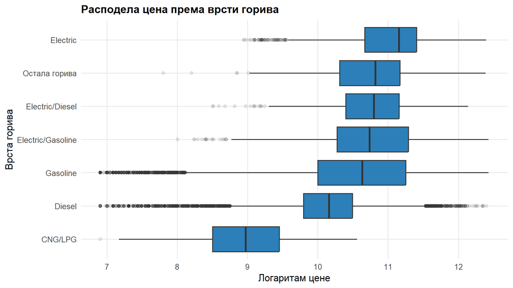

Расподела цена према врсти горива

```r
gorivo_cena %>%
  ggplot(aes(x = reorder(gorivo_grupa, log_price, FUN = median), y = log_price)) +
  geom_boxplot(fill = BOJA_1, outlier.alpha = 0.1) +
  coord_flip() +
  labs(title = "Расподела цена према врсти горива",
       x = "Врста горива", y = "Логаритам цене") +
  tema_rad()
```

### 6.3.2 Цена и спортски пакет

```r
sport_cena <- auta_fe %>%
  filter(make %in% c("BMW", "Audi", "Mercedes-Benz"))

uporedi_grupe(sport_cena, "log_price", "ima_sport_paket")
```

```
## Обележје: log_price по групама обележја ima_sport_paket
## Број група: 2  | Укупно опсервација: 53850
##
## # A tibble: 2 × 5
##   grupa     n медијана `ср. вред.` `ст. дев.`
##   <fct> <int>    <dbl>       <dbl>      <dbl>
## 1 FALSE 39465     10.3        10.4       0.78
## 2 TRUE  14385     10.5        10.5       0.5
##
## H0: Медијане/средине две групе су једнаке.
## H1: Медијане/средине две групе се разликују.
##
## --- Студентов t-тест (Велч) ---
##
##  Welch Two Sample t-test
##
## data:  vred by grupa
## t = -31.237, df = 40202, p-value < 2.2e-16
## alternative hypothesis: true difference in means between group FALSE and group TRUE is not equal to 0
## 95 percent confidence interval:
##  -0.1901370 -0.1676847
## sample estimates:
## mean in group FALSE  mean in group TRUE
##            10.35863            10.53754
##
## --- Вилкоксонов тест ---
##
##  Wilcoxon rank sum test with continuity correction
##
## data:  vred by grupa
## W = 239755034, p-value < 2.2e-16
## alternative hypothesis: true location shift is not equal to 0
```

Пошто су групе само две, користе се Велчов t-тест и Вилкоксонов тест. Оба показују значајну разлику: медијана цене возила са спортским пакетом је 35.440 EUR наспрам 30.000 EUR код возила без њега.

> **Ограничење закључка.** Поређење није контролисано по старости возила. Возила са евидентираним спортским пакетом су у просеку знатно млађа, а старост је једно од најјачих обележја у вези са ценом. Део разлике зато потиче од старости, не од самог пакета. Биваријантна анализа може да покаже да веза постоји, али не и да је узрочна — за раздвајање тих ефеката потребан је модел који их процењује истовремено, што је предмет поглавља 7.

# 7 Анализа нумеричких података и моделирање

## 7.1 Креирање нових обележја (feature engineering)

Изворна обележја описују возило онако како је оглас написан. Модел, међутим, боље ради са величинама које носе **однос** између изворних вредности, или које из слободног текста извлаче структурирану информацију. У овом поглављу уводи се 21 ново обележје, груписано у пет целина.

### 7.1.1 Опрема из текстуалних колона

Четири колоне (`equipment_comfort`, `equipment_safety`, `equipment_entertainment`, `equipment_extra`) садрже листе ставки опреме записане као текст, у облику `'Navigacija', 'Grejanje sedišta', ...`. Помоћна функција `izvuci_opcije()` раставља тај запис, а `broj_opcija()` броји ставке.

```r
auta <- auta %>%
  mutate(
    broj_komfor      = broj_opcija(equipment_comfort),
    broj_bezbednost  = broj_opcija(equipment_safety),
    broj_multimedija = broj_opcija(equipment_entertainment),
    broj_dodatna     = broj_opcija(equipment_extra)
  )
```

Бројачи ставки опреме по категоријама

| Обележје | Медијана | Максимум | r са log(цена) |
| --- | --- | --- | --- |
| Комфор | 18 | 42 | 0.281 |
| Безбедност | 18 | 36 | 0.187 |
| Мултимедија | 7 | 16 | 0.246 |
| Додатна | 6 | 37 | 0.245 |

Код 5.170 возила ниједна од четири колоне није попуњена. Њима збир износи нулу, што је вредност коју модел не би умео да разликује од возила које стварно нема опрему. Зато је уведен индикатор `oprema_nije_navedena`, који ту разлику чува.

### 7.1.2 Индикатори појединачне опреме

Број ставки говори колико опреме возило има, али не и **која**. Зато је за десет ставки које се у огласима најчешће истичу уведен засебан логички индикатор.

Индикатори опреме и разлика у медијани цене

| Опрема | Удео возила (%) | Медијана са (EUR) | Медијана без (EUR) | Разлика (%) |
| --- | --- | --- | --- | --- |
| Електрична седишта | 47.7 | 49.990.0 | 25.840 | 93.5 |
| Панорамски кров | 25.6 | 55.000.0 | 29.900 | 83.9 |
| Apple CarPlay | 42.1 | 48.790.0 | 27.290 | 78.8 |
| Надзор мртвог угла | 28.0 | 51.900.0 | 29.400 | 76.5 |
| Камера за паркирање | 49.8 | 42.900.0 | 26.400 | 62.5 |
| Head-up дисплеј | 21.1 | 50.000.0 | 30.900 | 61.8 |
| Адаптивни темпомат | 33.4 | 47.978.5 | 29.850 | 60.7 |
| Дигитални кокпит | 38.1 | 44.900.0 | 28.499 | 57.5 |
| Амбијентално осветљење | 38.9 | 42.990.0 | 29.500 | 45.7 |
| Full-LED фарови | 25.5 | 39.909.0 | 32.470 | 22.9 |

Разлике су изразите, али их треба читати опрезно: опрема попут head-up дисплеја се не уграђује насумично него у скупље моделе, па разлика у медијани мери и класу возила а не само вредност саме опреме.

### 7.1.3 Односи између техничких величина

```r
auta <- auta %>%
  mutate(
    snaga_po_toni   = if_else(power_hp > 0 & masa_kg > 0,
                              power_hp / (masa_kg / 1000), NA_real_),
    log_km          = log1p(mileage_km_raw),
    starost_kvadrat = starost_god^2
  )
```

**`snaga_po_toni`** је однос снаге и масе, мера која боље описује карактер возила од снаге саме: 200 KS у лаком купеу и у тешком теренцу нису иста ствар. Медијана износи 126.3 KS по тони, а корелација са `log_price` 0.67.

**`log_km`** је логаритамска трансформација километраже, преко `log1p()` да би вредност нула остала дефинисана. Утицај километраже на цену није линеаран: разлика између 10.000 и 50.000 пређених километара вреднија је од разлике између 210.000 и 250.000, иако је у оба случаја реч о 40.000 km.

**`starost_kvadrat`** омогућава моделу да ухвати нелинеарно опадање цене са годинама, што је биваријантна анализа већ наговестила разликом Пирсоновог и Спирмановог коефицијента.

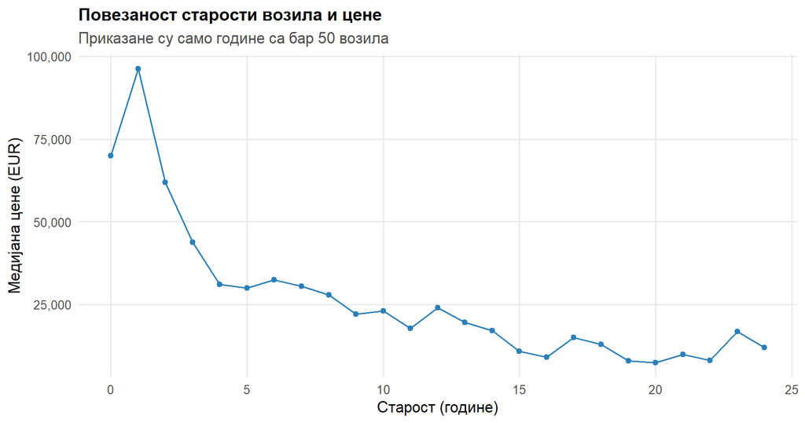

Медијана цене по навршеној години старости

```r
auta_fe %>%
  mutate(godina = floor(starost_god)) %>%
  group_by(godina) %>%
  summarise(medijana = median(price), n = n(), .groups = "drop") %>%
  filter(n >= 50) %>%
  ggplot(aes(godina, medijana)) +
  geom_point(color = BOJA_1) +
  geom_line(color = BOJA_1) +
  scale_y_continuous(labels = scales::comma) +
  labs(title = "Повезаност старости возила и цене",
       subtitle = "Приказане су само године са бар 50 возила",
       x = "Старост (године)", y = "Медијана цене (EUR)") +
  tema_rad()
```

Крива потврђује претпоставку: пад је најстрмији у прве три-четири године, после чега постаје знатно блажи. Осцилације код најстаријих возила последица су различите заступљености марки — у тој групи преовлађују возила која се чувају, не она која се троше.

### 7.1.4 Агрегација модела возила

Колона `model` има 561 ниво, од којих многи имају свега неколико возила. Ниво са малим бројем опсервација даје нестабилну процену коефицијента и лако доводи до преприлагођавања. Зато се модели са мање од 50 примерака сажимају у заједничку категорију унутар своје марке.

```r
ucestalost_modela <- auta %>% count(make, model, name = "broj_primeraka")

auta <- auta %>%
  left_join(ucestalost_modela, by = c("make", "model")) %>%
  mutate(model_grupa = if_else(broj_primeraka >= 50,
                               paste(make, model, sep = "_"),
                               paste(make, "Other", sep = "_"))) %>%
  select(-broj_primeraka)
```

Резултат је 235 нивоа уместо 561, при чему 4.232 возила припада сабирним категоријама. Ниједна опсервација није изгубљена, а свака категорија сада има довољно примерака за стабилну процену.

### 7.1.5 Препознавање пакета опреме из ознаке верзије

Колона `model_version` садржи слободан текст са 70.014 различитих вредности, па као категоријско обележје нема употребну вредност. Из ње се ипак може извући структурирана информација: произвођачи означавају спортске пакете опреме устаљеним називима — *M Sport* код BMW-а, *AMG Line* код Mercedes-а, *S line* код Audi-ја. Индикатор `ima_sport_paket` обухвата 14.385 возила.

Пошто су ти називи дефинисани само за три марке, индикатор се користи искључиво у анализама ограниченим на BMW, Audi и Mercedes-Benz. Код 674 огласа без наведене верзије индикатор је постављен на `FALSE`, уз напомену да то значи „није евидентирано”, а не поуздано одсуство пакета; информација о ненаведеној опреми чува се у засебном индикатору.

Сама колона `model_version`, као и четири текстуалне колоне са опремом и колона `description`, уклањају се на крају ове скрипте — њихов садржај је већ преточен у бројачке и индикаторске колоне, а као слободан текст у модел не улазе.

## 7.2 Линеарна регресија и дијагностика

> Модели у овом одељку процењују се у скрипти `08_modeli_lin.R`. Пун модел има преко 360 коефицијената над 75.000 опсервација, па се у извештају приказује код и резултати извршења, уместо да се процена понавља при сваком превођењу документа.

### 7.2.1 Припрема табеле за моделирање

Линеарна регресија не трпи **тачне линеарне зависности** међу предикторима. Ако је једна колона тачна линеарна комбинација других, матрица модела губи пун ранг, функција `lm()` одбацује коефицијент и уписује `NA`, а рачунање VIF-а постаје немогуће. Такве колоне се зато уклањају свесно и уз образложење, уместо да се избор препусти функцији.

Колоне искључене из модела и разлог искључења

| Колона | Разлог |
| --- | --- |
| price | циљна променљива у изворној скали |
| model | 561 ниво и 683 недостајуће вредности; замењује је model_grupa |
| registration_date | starost_god је изведена из ње, носе исту информацију |
| make | model_grupa већ садржи марку, дупло кодирање |
| je_elektricno | тачна функција обележја fuel_category |
| broj_opreme_ukupno | тачан збир четири компоненте, које се задржавају |
| had_accident | свега 3 вредности TRUE на 93.718 редова |
| imput_mileage_km_raw | свега 4 вредности TRUE |

Девета зависност откривена је тек при првом покретању модела. Ниво `"непознато"` код `seller_type` има свега 12 опсервација, и то **тачно истих 12** које имају `"непознато"` и код `country_code`. Две индикаторске колоне су тиме идентичне. Реч је о истом **монотоном обрасцу недостајања** утврђеном у поглављу 5 код оцена продавца: оглас коме недостаје један податак по правилу нема ни остале. Информација се задржава једном, у `country_code`, а код `seller_type` се тих 12 редова своди на доминантни ниво.

### 7.2.2 Подела на тренинг и тест

```r
set.seed(SEME)
indeks_trening <- sample(seq_len(nrow(model_podaci)),
                         size = floor(0.8 * nrow(model_podaci)))
```

Скуп је подељен у односу 80:20, што даје 74.974 возила за учење и 18.744 за оцену. Подела се снима заједно са подацима, у колони `skup`, да би модели у одељку 7.3 користили **исту** поделу — иначе поређење не би било исправно.

### 7.2.3 Мали модел

Пре пуног модела гради се мали модел од шест обележја, као полазна тачка коју сваки сложенији модел мора да надмаши да би сложеност била оправдана.

```r
model_mali <- lm(log_price ~ power_hp + starost_god + mileage_km_raw +
                   masa_kg + fuel_category + transmission, data = trening)
```

Пошто је циљна променљива логаритмована, коефицијенти се тумаче **мултипликативно**: коефицијент *b* значи да пораст предиктора за једну јединицу мења цену за фактор exp(*b*).

Одабрани коефицијенти малог модела (R² = 0,826)

| Обележје | b | exp(b) | Промена цене (%) |
| --- | --- | --- | --- |
| power_hp (по KS) | 0.00369 | 1.0037 | 0.37 |
| starost_god (по години) | -0.03099 | 0.9695 | -3.05 |
| masa_kg (по kg) | 0.00011 | 1.0001 | 0.01 |
| transmission: Manual | -0.28660 | 0.7509 | -24.90 |
| fuel_category: Electric | -0.26890 | 0.7642 | -23.60 |
| fuel_category: Diesel | 0.15970 | 1.1731 | 17.30 |

Свака година старости смањује цену за око 3%, а ручни мењач је повезан са скоро 25% нижом ценом. Негативан коефицијент код електричних возила делује супротно очекивању — она су најскупља у скупу — али овде је реч о ефекту **при истој снази, маси и километражи**. Управо то је разлика између биваријантне анализе и регресије.

### 7.2.4 Пун модел

```r
model_pun <- lm(log_price ~ ., data = trening)
```

Пун модел — резултати извршења скрипте 08_modeli_lin.R

| Мера | Вредност |
| --- | --- |
| Број процењених коефицијената | 367 |
| R² (логаритамска скала) | 0,9551 |
| Кориговани R² | 0,9549 |
| Резидуална стандардна грешка | 0,1915 |
| Значајних коефицијената (p < 0,05) | 318 од 366 |

Најјачи појединачни ефекти долазе од обележја `model_grupa`: појединачни Porsche модели повезани су са вишеструко вишом ценом у односу на референтну категорију. То је очекивано и потврђује да агрегација модела из одељка 7.1 носи стварну информацију.

Да 318 од 366 коефицијената буде статистички значајно не треба тумачити као квалитет модела. При 75.000 опсервација тест открива и ефекте који су практично занемарљиви, па је **величина ефекта важнија од p-вредности**.

### 7.2.5 Мултиколинеарност

Фактор инфлације варијансе мери колико је варијанса процењеног коефицијента увећана због повезаности тог предиктора са осталима. Вредност 1 значи потпуну независност, преко 5 умерен проблем, преко 10 озбиљан. За категоријска обележја користи се уопштена верзија GVIF, а пореди се величина `GVIF^(1/(2·Df))` подигнута на квадрат, да би била упоредива са обичним VIF-ом без обзира на број нивоа.

Обележја са највећим VIF-ом (извршење скрипте 08)

| Обележје | Еквивалент VIF |
| --- | --- |
| power_hp | 76.50 |
| snaga_po_toni | 72.50 |
| starost_god | 51.10 |
| starost_kvadrat | 30.20 |
| masa_kg | 17.50 |
| imput_potrosnja | 17.50 |
| cylinders_volume_cc | 15.10 |
| cylinders | 12.80 |
| broj_komfor | 12.50 |
| broj_bezbednost | 8.55 |
| co2 | 8.12 |
| potrosnja | 8.08 |

Девет обележја прелази праг 10. Код `power_hp` вредност 76,5 значи да је варијанса процене увећана 76,5 пута, односно да је **стандардна грешка увећана око 8,7 пута** у односу на ситуацију да је то обележје независно од осталих. Коефицијент остаје непристрасан, али постаје толико нестабилан да га није смислено тумачити: мала промена узорка даје битно другачију вредност.

Извори су познати из претходних поглавља — више обележја мери исту физичку особину возила:

Најјаче везе међу предикторима

| Пар | r |
| --- | --- |
| starost_god ~ starost_kvadrat | 0.942 |
| cylinders ~ cylinders_volume_cc | 0.920 |
| snaga_po_toni ~ power_hp | 0.901 |
| potrosnja ~ co2 | 0.762 |
| mileage_km_raw ~ log_km | 0.704 |

Два налаза заслужују посебан коментар.

Пар `potrosnja ~ co2` делом је **последица нашег сопственог поступка**. У поглављу 5 емисија CO₂ је за 44.588 возила, скоро половину скупа, попуњена регресијом управо из потрошње и врсте горива. За те редове `co2` није независно измерен податак него детерминистичка функција потрошње, што вештачки појачава њихову повезаност. То је ограничење импутације, не особина тржишта.

Индикатор `imput_potrosnja` са VIF-ом 17,5 изненађује док се не погледа његова структура: он је `TRUE` за свих 4.105 електричних возила, јер им је потрошња у поглављу 4 постављена на `NA` као неприменљива, а преклапа се и са `imput_co2` на 23.205 возила. Поново је реч о заједничком обрасцу недостајања — возило коме недостаје један технички податак по правилу нема ни остале.

Обележје `model_grupa`, иако чини највећи део од 367 коефицијената, **није** међу проблематичнима. Мултиколинеарност не долази од броја нивоа него од преклапања нумеричких обележја.

### 7.2.6 Дијагностика резидуала

Линеарна регресија почива на четири претпоставке: линеарности везе, константној варијанси грешке, нормалности резидуала и независности опсервација. Свака се проверава засебно.

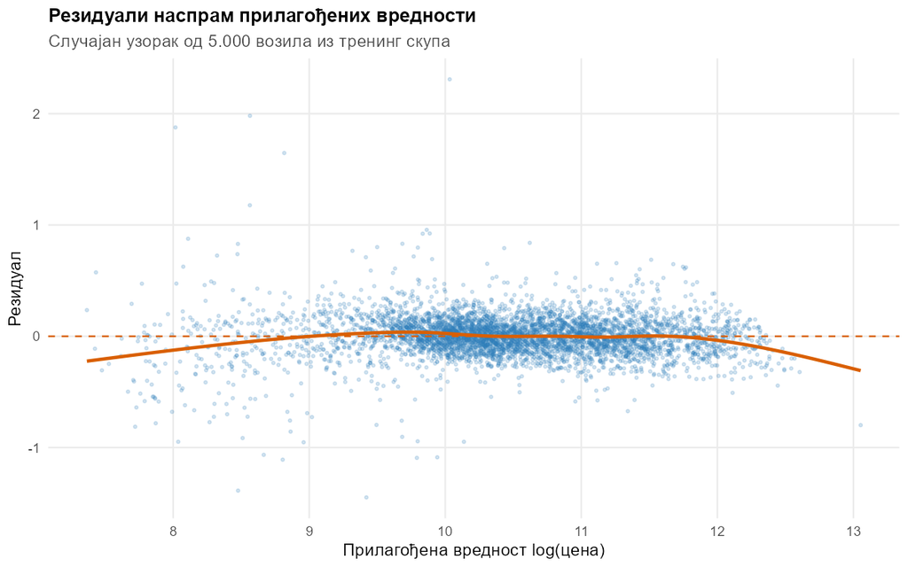

Резидуали наспрам прилагођених вредности

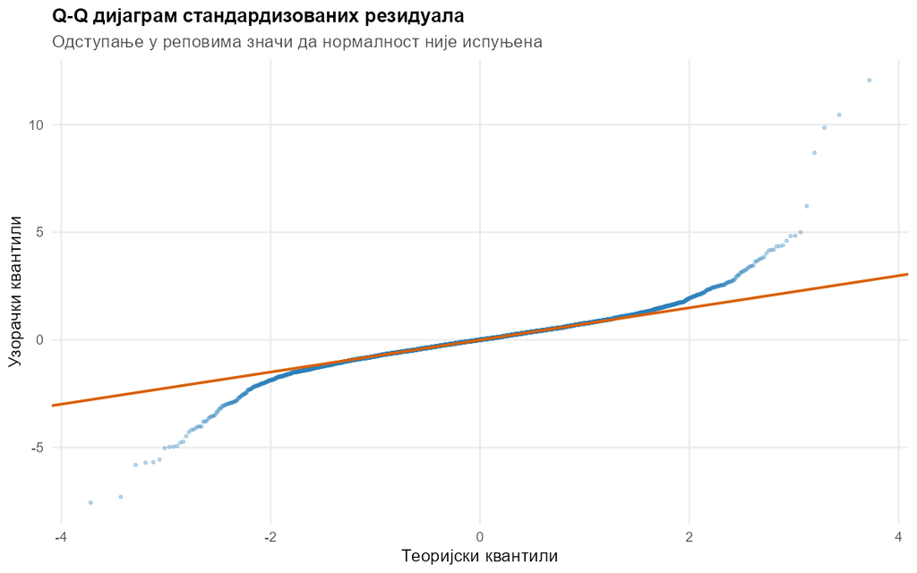

Q-Q дијаграм стандардизованих резидуала

Средишњи део прати теоријску линију, а одступања се јављају у реповима. То значи да модел најлошије предвиђа крајње јефтина и крајње скупа возила. Нормалност у строгом смислу није испуњена, али при овако великом узорку то не угрожава валидност тестова, због централне граничне теореме.

> **Зашто овде нема Шапиро-Вилковог теста.** Он је у R-у ограничен на 5.000 опсервација. Независно од тога, при узорку од 75.000 сваки тест нормалности одбацује нулту хипотезу и због занемарљивог одступања, па његов резултат не носи корисну информацију. Из истог разлога се нормалност процењује графички.

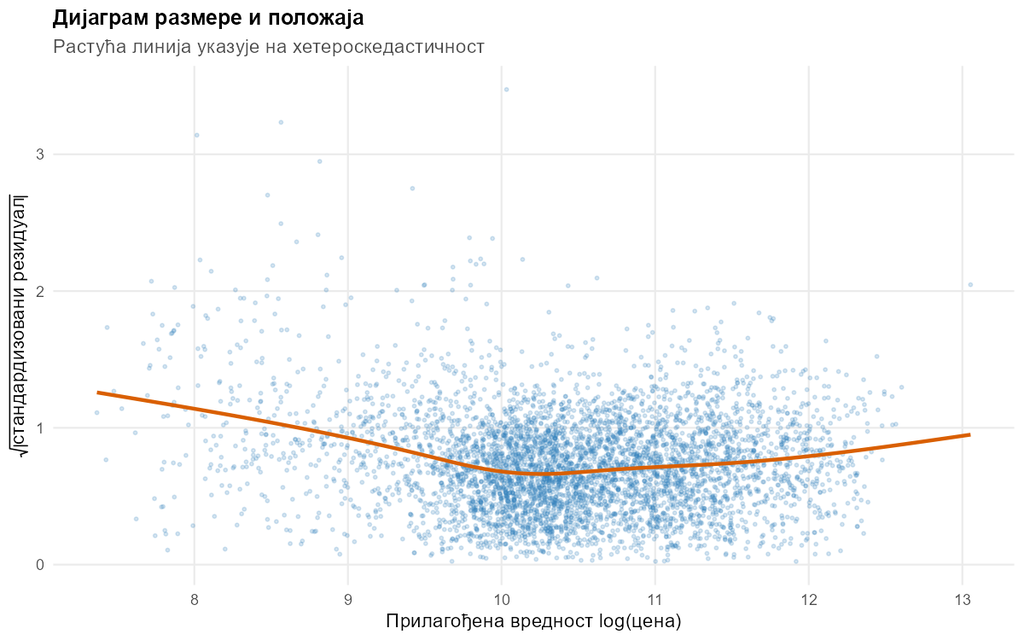

Дијаграм размере и положаја

Четврта претпоставка, независност опсервација, **није испуњена** и то се не може поправити дијагностиком. Исти продавац поставља више огласа, а иста конфигурација возила појављује се више пута. Ово ограничење разматра се у поглављу 8.

### 7.2.7 Утицајне опсервације

Куково растојање мери колико се процене свих коефицијената промене када се једна опсервација избаци из модела.

Куково растојање (извршење скрипте 08)

| Мера | Вредност |
| --- | --- |
| Праг 4/n | 0,0000534 |
| Опсервација изнад прага | 4.164 (5,55%) |
| Највеће Куково растојање | 0,0109 |

Највећа вредност износи 0,0109, дубоко испод уобичајеног прага од 1 — ниједна појединачна опсервација не доминира моделом. Праг 4/n означи 5,55% скупа, што је последица строгости тог правила при великом узорку, а не доказ да је толики део података погрешан.

Најутицајнија опсервација је Honda са оглашеном ценом од 182.350 EUR коју модел процењује на 16.181 EUR. Са 114 KS и 13 година старости то готово сигурно није колекционарско возило него грешка при уносу цене. **Опсервације се не уклањају** — осетљивост обичне регресије на такве тачке један је од разлога за прелазак на регуларизоване моделе у одељку 7.3.

### 7.2.8 Смањен модел и оцена на тест скупу

Из пуног модела уклоњено је пет најповезанијих обележја (`starost_kvadrat`, `log_km`, `snaga_po_toni`, `cylinders`, `co2`), да би се проверило колико информације заиста носе.

Оцена на тест скупу (18.744 возила)

| Модел | RMSE (EUR) | MAE (EUR) | R² | MAPE (%) |
| --- | --- | --- | --- | --- |
| мали (6 обележја) | 27.753 | 14.605 | 0.594 | 29.8 |
| смањен | 12.361 | 6.416 | 0.919 | 13.6 |
| пун | 12.222 | 6.310 | 0.921 | 13.4 |

Метрике су рачунате у **еврима**, не у логаритамској скали: предикције се пре рачунања враћају функцијом `exp()`, јер грешка од 0,19 у логаритму не говори ништа. Зато се R² овде (0,921) разликује од R² који даје `summary()` (0,9551) — прва вредност је у изворној, друга у логаритамској скали.

Уклањање пет обележја мења R² за свега 0,0011, а MAPE за 0,2 процентна поена. Фишеров тест угнежђених модела истовремено даје F = 369,8 уз p < 2,2 · 10⁻¹⁶, дакле налази да су та обележја **заједно статистички значајна**. Та два налаза нису противречна: при 75.000 опсервација тест поуздано открива и ефекат који је практично безначајан. То је један од најважнијих закључака овог поглавља.

Поређење тренинга и теста не показује преприлагођавање — пун модел даје MAPE 13,4% и R² 0,921 на оба скупа, иако има 367 коефицијената.

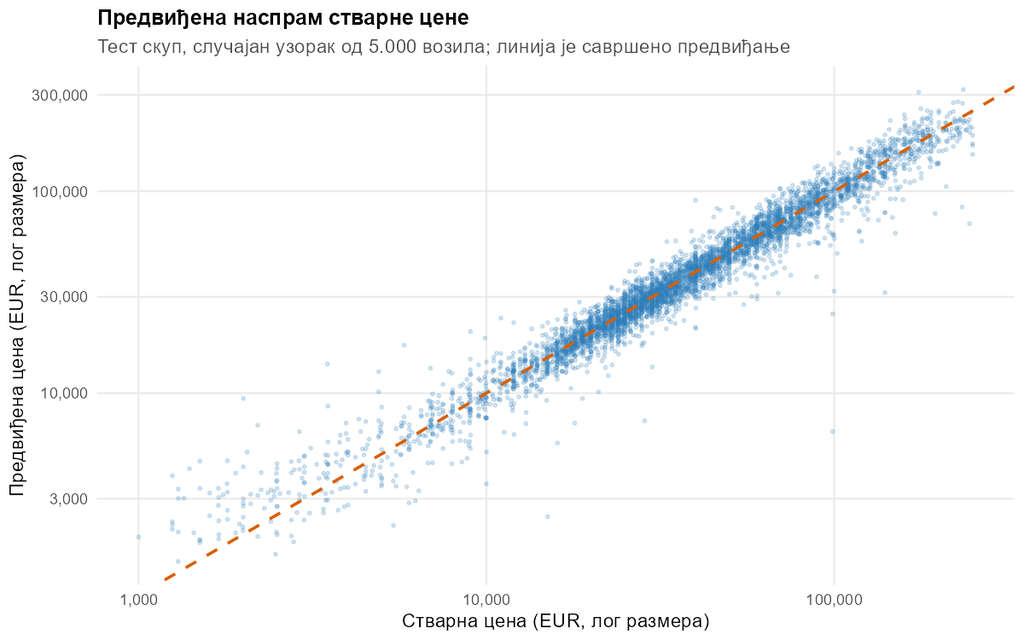

Предвиђена наспрам стварне цене на тест скупу

Тачке су збијене око дијагонале на целом распону цена, уз веће расипање на оба краја — исти налаз који је показао и Q-Q дијаграм.

## 7.3 Регуларизација: гребена и ласо регресија

> Модели у овом одељку процењени су у скрипти `09_modeli_reg.R`. У извештају су приказани поступак и резултати извршавања, без поновног тренирања приликом превођења документа.

### 7.3.1 Мотивација и основни принцип

У претходном одељку пун линеарни модел је постигао добре резултате на тест скупу, али је анализа мултиколинеарности показала да 9 обележја има VIF већи од 10. Посебно се издвајају `power_hp` (76,5) и `snaga_po_toni` (72,5). Висока повезаност предиктора отежава поуздано тумачење појединачних коефицијената, чак и када су предвиђања прецизна. Зато испитујемо гребену (*Ridge*) и ласо (*Lasso*) регресију, које у функцију грешке уводе казну за величину коефицијената.

За гребену регресију казна је збир квадрата коефицијената (L2):

$$\sum_{i=1}^{n}(y_i-\hat{y}_i)^2 + \lambda\sum_{j=1}^{p}\beta_j^2.$$

За ласо регресију казна је збир апсолутних вредности коефицијената (L1):

$$\sum_{i=1}^{n}(y_i-\hat{y}_i)^2 + \lambda\sum_{j=1}^{p}|\beta_j|.$$

Ови изрази приказују принцип регуларизације: имплементација у пакету `glmnet` користи сопствену нормализацију функције циља. Параметар $\lambda$ одређује јачину казне: већа вредност снажније смањује коефицијенте. Гребена регресија их не поставља тачно на нулу, док ласо може да елиминише поједине коефицијенте. Слободни члан се не кажњава.

### 7.3.2 Припрема података и избор параметра $\lambda$

Учитава се `auta_model.rds`, припремљен у скрипти `08_modeli_lin.R`. Задржана је **иста подела** од 74.974 возила за тренинг и 18.744 за тест, записана у колони `skup`. Поновна случајна подела би отежала исправно поређење са линеарном регресијом. Циљна променљива остаје `log_price`.

Пошто `glmnet()` захтева нумеричку матрицу, категоријска обележја су претворена у индикаторске колоне помоћу `model.matrix()`. Слободни члан ове матрице је уклоњен, пошто га `glmnet` додаје сам. Предиктори се стандардизују (`standardize = TRUE`) да казна не би зависила од мерних јединица обележја.

```r
auta <- ucitaj("auta_model")
x <- model.matrix(log_price ~ . - skup, data = auta)[, -1, drop = FALSE]
y <- auta$log_price

ind_trening <- auta$skup == "trening"
ind_test <- auta$skup == "test"
x_trening <- x[ind_trening, , drop = FALSE]
x_test <- x[ind_test, , drop = FALSE]
y_trening <- y[ind_trening]
y_test <- y[ind_test]

# Исте поделе десетоструке унакрсне валидације за оба модела.
set.seed(SEME)
foldid <- sample(rep(1:10, length.out = nrow(x_trening)))

cv_ridge <- cv.glmnet(x_trening, y_trening,
                      alpha = 0, foldid = foldid,
                      standardize = TRUE, type.measure = "mse")
cv_lasso <- cv.glmnet(x_trening, y_trening,
                      alpha = 1, foldid = foldid,
                      standardize = TRUE, type.measure = "mse")

pred_ridge <- predict(cv_ridge, newx = x_test, s = "lambda.min")
pred_lasso <- predict(cv_lasso, newx = x_test, s = "lambda.min")

metrike_log(y_test, as.numeric(pred_ridge))
metrike_log(y_test, as.numeric(pred_lasso))
```

Параметар $\lambda$ је одабран десетоструком унакрсном валидацијом на тренинг скупу. За сваку испробану вредност рачуна се просечна квадратна грешка (MSE) на валидационим деловима **логаритмоване цене**. За коначне моделе изабрана је вредност `lambda.min`, са најмањом просечном валидационом грешком. Вредност `lambda.1se` даје јачу регуларизацију уз валидациону грешку унутар једне стандардне грешке од минимума, али није коришћена за коначно поређење. Тест скуп није учествовао у избору $\lambda$.

### 7.3.3 Гребена регресија

За гребену регресију постављен је `alpha = 0`, односно L2 казна. Коначни модел узима се из објекта `cv_ridge` за `lambda.min`, пошто `cv.glmnet()` поред валидације прилагођава моделе на целом тренинг скупу за низ вредности параметра.

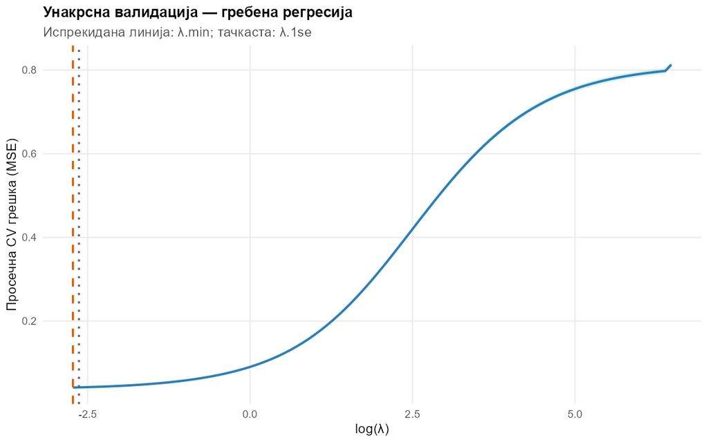

Гребена регресија: просечна валидациона грешка за различите вредности параметра λ

На графикону је приказан однос између $\log(\lambda)$ и просечне грешке унакрсне валидације. Осенчени део одговара распону једне стандардне грешке око процењене грешке. Испрекидана линија означава `lambda.min`, а тачкаста `lambda.1se`. Избор најмање валидационе грешке не гарантује и најмању грешку у еврима, јер су то различите скале и критеријуми.

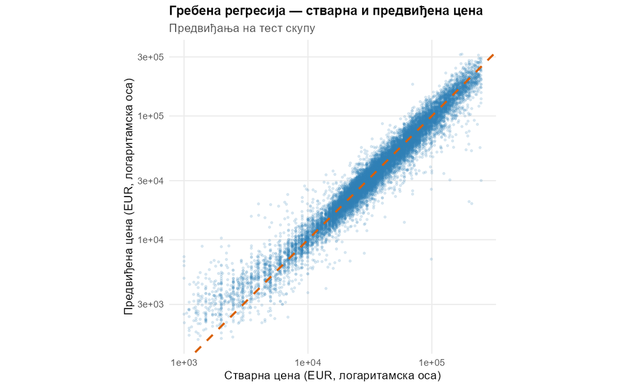

Гребена регресија: предвиђена наспрам стварне цене на тест скупу

На другом графикону идеална предвиђања налазе се на дијагонали. Тачке изнад ње означавају прецењивање, а испод ње потцењивање стварне цене. Обе осе су логаритамске ради прегледнијег поређења возила различитих ценовних распона, док су саме вредности приказане у еврима.

### 7.3.4 Ласо регресија и селекција коефицијената

За ласо регресију постављено је `alpha = 1`, што одговара L1 казни. Користе се иста обележја, иста тренинг/тест подела и исти валидациони делови као код гребене регресије. Оптимална вредност $\lambda$ се ипак бира посебно, јер је облик казне различит.

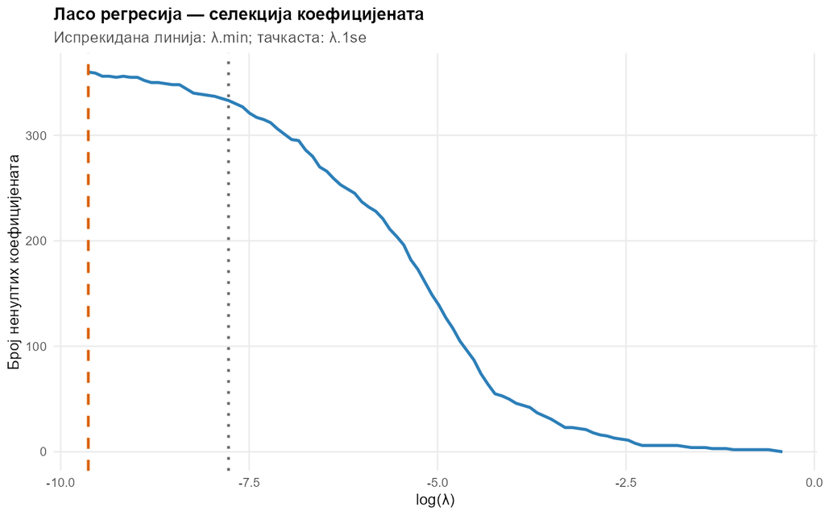

Ласо регресија: број ненултих коефицијената у зависности од јачине регуларизације

Са растом параметра $\lambda$ број ненултих коефицијената се смањује: ласо постепено искључује поједине индикаторске и нумеричке предикторе. За изабрану вредност `lambda.min` у забележеном извршењу елиминисано је **6 од 366 коефицијената** (1,64%), док је 360 остало ненулто. То је мала редукција, па се не може тврдити да је добијен знатно једноставнији модел. Бројеви се односе на коефицијенте након кодирања категорија, а не нужно на број оригиналних обележја.

### 7.3.5 Резултати на тест скупу

Коначна процена обављена је на истих 18.744 возила. За обрачун RMSE, MAE, R² и MAPE предвиђања су функцијом `exp()` враћена са логаритамске скале на изворну скалу цене, преко заједничке функције `metrike_log()`.

Резултати регуларизованих модела на тест скупу (извршење скрипте 09)

| Модел | RMSE (EUR) | MAE (EUR) | R² | MAPE (%) |
| --- | --- | --- | --- | --- |
| гребена регресија | 12.199 | 6.501 | 0.922 | 14.3 |
| ласо регресија | 12.273 | 6.340 | 0.920 | 13.6 |

Гребена регресија има нешто мањи RMSE (12.199 EUR), али већу средњу апсолутну и процентуалну грешку од ласо регресије. Ласо има RMSE од 12.273 EUR, а MAE од 6.340 EUR. Ови налази показују да предност једног модела зависи и од изабране метрике; није оправдано издвојити један модел као бољи према свим критеријумима.

У односу на пун линеарни модел из одељка 7.2 (RMSE 12.222 EUR, MAE 6.310 EUR), оба регуларизована модела имају веома сличну предиктивну успешност. Гребена регресија незнатно смањује RMSE, али не побољшава MAE и MAPE. Ласо уклања мали број коефицијената уз занемарљиву промену тачности. Према томе, регуларизација је у овом експерименту корисна пре свега као поступак за контролу величине коефицијената и испитивање мултиколинеарности, а не као доказано значајно побољшање предвиђања. Свеобухватно поређење модела остављено је за одељак 7.5.

## 7.4 Додатни алгоритам: Random Forest регресија

> Модел у овом одељку обучен је у скрипти `10_modeli_rf.R`. У извештају су приказани примењени поступак, резултати извршавања и њихово тумачење. Подаци и подела на тренинг и тест су исти као у претходним деловима.

### 7.4.1 Мотивација и принцип рада

Претходно анализирани линеарни модели показали су сличну тачност предвиђања, али се код њих полази од линеарног облика везе између предиктора и логаритмоване цене. На тржишту половних аутомобила односи могу бити сложенији: утицај километраже може зависити од старости возила, а значај снаге мотора од модела, тежине и других карактеристика. Зато је као додатни приступ испитана **Random Forest регресија**, која може да обухвати нелинеарности и интеракције без њиховог експлицитног задавања у формули модела.

Random Forest је ансамбл стабала одлучивања. Појединачна стабла се граде на случајним узорцима тренинг података са понављањем (**bootstrap**), док се при сваком раздвајању разматра насумично изабран подскуп предиктора. Код регресије коначно предвиђање добија се **усредњавањем предвиђања свих стабала**. Случајност у избору узорака и предиктора доприноси смањењу зависности између стабала и стабилнијим предвиђањима.

### 7.4.2 Припрема података и тренирање

Коришћен је исти скуп `auta_model.rds`, са **74.974 опсервације за тренирање** и **18.744 за тестирање**. Циљна променљива је `log_price`, као и код претходних модела. Колона `skup` служи само за поделу података и искључена је из предиктора. За разлику од библиотеке `glmnet`, имплементација `ranger` може непосредно да ради са факторским обележјима, па није било потребно формирање индикаторске матрице.

Коришћено је **300 стабала**, док је број разматраних обележја при сваком раздвајању одређен као цео део квадратног корена броја предиктора (`mtry`). Минимална величина завршеног чвора постављена је на **10**. Параметри су унапред задати; у овом кораку није спроведено систематско подешавање хиперпараметара. Ради поновљивости постављено је исто семе случајног генератора.

```r
auta <- ucitaj("auta_model")
trening <- auta %>% filter(skup == "trening") %>% select(-skup)
test    <- auta %>% filter(skup == "test") %>% select(-skup)

p <- ncol(trening) - 1L
set.seed(SEME)
rf <- ranger::ranger(
  log_price ~ ., data = trening,
  num.trees = 300,
  mtry = max(1L, floor(sqrt(p))),
  min.node.size = 10,
  splitrule = "variance",
  respect.unordered.factors = "order",
  importance = "permutation",
  seed = SEME,
  write.forest = TRUE
)

pred_test_log <- predict(rf, data = test)$predictions
rez_rf <- metrike_log(test$log_price, as.numeric(pred_test_log))
rez_rf
rf$prediction.error
```

### 7.4.3 Резултати на тест скупу

Након тренирања, предвиђања на логаритамској скали враћена су у евре функцијом `exp()`, а метрике су израчунате за издвојени тест скуп, на исти начин као за остале моделе.

Резултати Random Forest регресије на тест скупу (18.744 возила)

| Модел | RMSE (EUR) | MAE (EUR) | R² | MAPE (%) |
| --- | --- | --- | --- | --- |
| Random Forest | 8.825 | 4.474 | 0.959 | 10.6 |

Добијен је **RMSE од 8.825 EUR**, док **MAE износи 4.474 EUR**. Вредност **R² = 0,959** показује да модел, према употребљеној дефиницији метрике, објашњава приближно 95,9% варијабилности цена у тест скупу на скали евра. **MAPE од 10,6%** представља просечну апсолутну процентуалну грешку предвиђања. Резултати су осетно бољи од добијених код претходно испитаних линеарних модела.

Поред тест метрика, `ranger` је израчунао **out-of-bag (OOB) MSE од 0,0247**. Ова грешка добија се помоћу опсервација које нису коришћене за изградњу појединачних стабала. Пошто је циљана променљива `log_price`, OOB MSE је изражен на **логаритамској скали** и зато није директно упоредив са тест RMSE израженим у еврима.

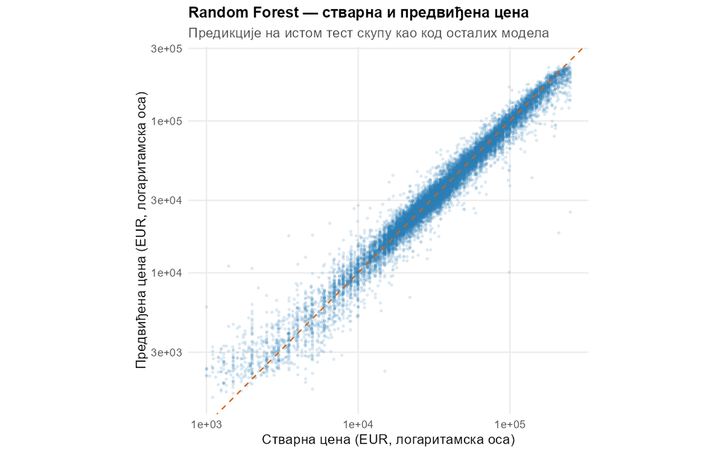

Random Forest: стварна и предвиђена цена на тест скупу

На графикону су упоређене стварне и предвиђене цене. Испрекидана дијагонала представља идеално предвиђање; веће одступање тачке од дијагонале означава већу грешку. Обе осе су логаритамске ради прегледнијег приказа широког распона цена, док су вредности и даље исказане у еврима.

### 7.4.4 Важност обележја

За процену значаја предиктора употребљена је **пермутациона важност** (*permutation importance*): вредности једног обележја насумично се измешају у OOB опсервацијама, након чега се посматра промена грешке предвиђања. Већа позитивна вредност значи да се модел више ослања на то обележје. Добијене вредности **нису проценти**, нити представљају узрочни утицај појединачног обележја на цену.

Осам најважнијих обележја према OOB пермутационој важности

| Обележје | Пермутациона важност |
| --- | --- |
| model_grupa | 0.1700 |
| power_hp | 0.1340 |
| starost_god | 0.0960 |
| starost_kvadrat | 0.0936 |
| cylinders_volume_cc | 0.0597 |
| log_km | 0.0549 |
| mileage_km_raw | 0.0534 |
| snaga_po_toni | 0.0532 |

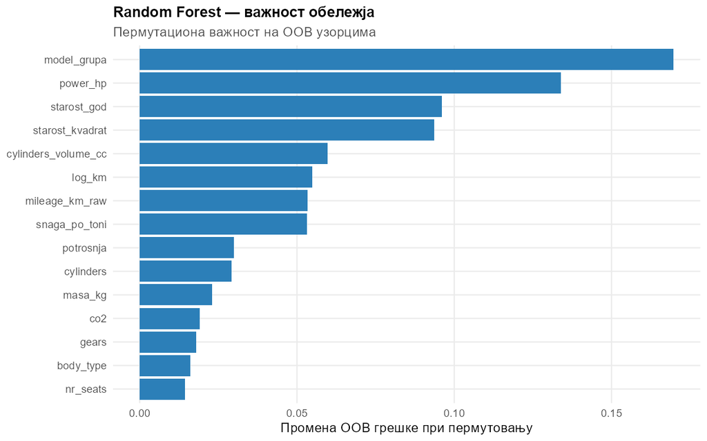

Random Forest: пермутациона важност 15 најважнијих обележја

Највећу важност има `model_grupa` (0,170), затим `power_hp` (0,134), `starost_god` (0,096) и `starost_kvadrat` (0,0936). Овакав редослед је у складу са очекивањем да цена половног возила у великој мери зависи од модела, снаге мотора и старости. Ипак, појединачна важност може бити потцењена или расподељена између снажно повезаних предиктора, као што су `starost_god` и `starost_kvadrat`, односно различити прикази километраже. Зато приказане вредности треба користити за тумачење предвиђања модела, а не за издвајање независних узрочних ефеката.

## 7.5 Поређење модела

Поређење регресионих модела на тест скупу

| Модел | RMSE (EUR) | MAE (EUR) | R² | MAPE (%) |
| --- | --- | --- | --- | --- |
| Мали линеарни | 27.753 | 14.605 | 0.594 | 29.8 |
| Смањени линеарни | 12.361 | 6.416 | 0.919 | 13.6 |
| Пуни линеарни | 12.222 | 6.310 | 0.921 | 13.4 |
| Гребена регресија | 12.199 | 6.501 | 0.922 | 14.3 |
| Ласо регресија | 12.273 | 6.340 | 0.920 | 13.6 |
| Random Forest | 8.825 | 4.474 | 0.959 | 10.6 |

Пуни линеарни модел, гребена и ласо регресија остварили су међусобно блиске резултате. Гребена регресија има нешто мањи RMSE од пуног линеарног модела, али не и мањи MAE или MAPE. Ласо регресија није донела значајнији напредак у предиктивној тачности при изабраној јачини регуларизације.

**Random Forest је остварио најбоље резултате према све четири приказане метрике.** У поређењу са гребеном регресијом, која међу претходним моделима има најмањи RMSE, смањио је RMSE са 12.199 на 8.825 EUR, односно приближно **27,7%**. У односу на пуни линеарни модел, који међу претходним моделима има најмањи MAE, смањио је MAE са 6.310 на 4.474 EUR, односно за око **29,1%**. Вредност R² порасла је до 0,959, а MAPE је смањен на 10,6%.

# 8 Ограничења рада

Ограничења су груписана у два дела: прво она која потичу од самог извора података, затим она која уводи наш поступак обраде и моделирања. Свако утиче на то како се резултати смеју тумачити.

## 8.1 Цена је тражена, а не постигнута

Циљна променљива `price` је цена **из огласа**, дакле износ који продавац тражи, а не износ по коме је возило заиста продато. Скуп не садржи податак о томе да ли је оглас уопште завршен продајом, нити по којој цени.

Последице су двојаке. Тражене цене су по правилу више од постигнутих, па модел систематски процењује горњу границу тржишне вредности, не њен центар. Уз то, простор за погађање није једнак код свих возила — индикатор `price_negotiable` показује да је код 6.9% огласа цена означена као преговарачка, што значи да иста тражена цена не носи исто значење у свим огласима.

Модел се зато исправно тумачи као процена **цене којом би возило било оглашено**, што је корисно продавцу који поставља оглас или купцу који проверава да ли је тражена цена у складу са тржиштем. Процена постигнуте цене захтевала би податке о реализованим трансакцијама, који овом скупу нису доступни.

## 8.2 Временски пресек

Скуп је снимак огласа на дан 08.11.2025. године. Све процене важе за стање тржишта тог дана и не садрже информацију о времену: нема податка о томе како се цена истог модела мењала кроз године, нити колико је оглас стајао активан.

То значи да модел не може да предвиђа будуће цене, него само да објасни разлике међу возилима у истом тренутку. Промене курса, цена горива, пореске политике или понуде нових модела непосредно утичу на цене половних возила, а ниједан од тих чинилаца у скупу не постоји. Са удаљавањем од датума снимка процене губе тачност, и то брже код сегмената у којима се тржиште брже мења — што се тренутно најјасније види код електричних возила.

## 8.3 Пристрасност узорка

```r
sirovi %>%
  count(make, sort = TRUE) %>%
  mutate(Проценат    = round(n / sum(n) * 100, 1),
         Кумулативно = round(cumsum(n) / sum(n) * 100, 1)) %>%
  head(6) %>%
  kable(caption = "Најзаступљеније марке у изворном скупу")
```

Најзаступљеније марке у изворном скупу

| make | n | Проценат | Кумулативно |
| --- | --- | --- | --- |
| BMW | 37745 | 31.9 | 31.9 |
| Porsche | 25511 | 21.5 | 53.4 |
| Mercedes-Benz | 19400 | 16.4 | 69.8 |
| Audi | 15469 | 13.1 | 82.9 |
| Alfa Romeo | 7806 | 6.6 | 89.5 |
| Suzuki | 4592 | 3.9 | 93.4 |

Четири премијум марке чине већину огласа. Стварно тржиште половних возила нема такву структуру — реч је о прикупљању усмереном на премијум сегмент. Закључци важе за марке и тржишта заступљена у скупу, а не за европско тржиште у целини.

## 8.4 Груписане опсервације

```r
sirovi %>%
  group_by(make, model, registration_date, mileage_km_raw, price) %>%
  filter(n() > 1) %>%
  summarise(n = n(),
            `различитих VIN` = n_distinct(vin, na.rm = TRUE),
            `различитих градова` = n_distinct(city),
            .groups = "drop") %>%
  arrange(desc(n)) %>%
  head(5) %>%
  kable(caption = "Записи са идентичном комбинацијом обележја")
```

Записи са идентичном комбинацијом обележја

| make | model | registration_date | mileage_km_raw | price | n | различитих VIN | различитих градова |
| --- | --- | --- | --- | --- | --- | --- | --- |
| Mercedes-Benz | GLB 180 | 2025-02-01 | NA | 43995 | 68 | 68 | 10 |
| Mercedes-Benz | CLA 180 | 2025-02-01 | NA | 39704 | 28 | 28 | 10 |
| Mercedes-Benz | A 250 | 2025-01-01 | 1 | 49190 | 23 | 0 | 5 |
| Mercedes-Benz | A 180 | 2025-02-01 | NA | 35622 | 21 | 21 | 6 |
| Mercedes-Benz | A 250 | 2025-01-01 | 10 | 47979 | 21 | 0 | 9 |

У скупу постоји већи број записа који деле исту комбинацију марке, модела, датума регистрације, километраже и цене. Провера бројева шасије показала је да **нису дупликати** — реч је о различитим возилима истог произвођача, огласним преко више салона по јединственој цени. Од тога око 6.500 записа остаје у радном скупу.

Таква возила нису међусобно независна, чиме је нарушена једна од претпоставки линеарне регресије. Практична последица је да ће стандардне грешке коефицијената бити благо потцењене, а p-вредности изгледати повољније него што јесу.

## 8.5 Избор доменских граница

Границе из поглавља 4 постављене су на основу познавања домена и представљају **одлуку аутора**, а не објективну чињеницу. Строжа граница уклања више погрешних вредности, али и више исправних. Пример: граница снаге мотора од 1.000 KS уклањала је четири исправна возила Porsche Taycan Turbo GT, па је подигнута на 1.500 KS — чиме су задржана и возила са 1.400 KS, за која се не може поуздано утврдити да ли су тјунована или погрешно уписана.

## 8.6 Поступак импутације

Два ограничења произлазе из поглавља 5.

**Смањена варијанса.** Импутација медијаном уметнутим вредностима не додељује сопствену варијансу, па стандардна девијација обрађених обележја опада. Код регресионе импутације емисије CO₂ ефекат је израженији, јер све уметнуте вредности леже тачно на регресионој површи. Последица је да ће стандардне грешке коефицијената бити благо потцењене. Напреднији поступци, попут вишеструке импутације (`mice`), ту слабост отклањају, али прелазе оквир овог рада.

Два обележја уведена у одељку 7.1 носе ограничења која треба имати у виду при тумачењу коефицијената.

**Сабирне категорије модела.** Обележје `model_grupa` сажима моделе са мање од 50 примерака у заједничку категорију унутар марке. Тиме је 4.232 возила сврстано у категорије попут `Honda_Other`, у којима се налазе међусобно веома различити модели. Коефицијент такве категорије представља просек преко хетерогене групе и не сме се тумачити као вредност конкретног модела. Управо отуда долази и највећа утицајна опсервација из одељка 7.2 — Honda са оглашеном ценом од 182.350 EUR.

**Индикатор спортског пакета.** Препознавање пакета из колоне `model_version` дефинисано је само за BMW, Audi и Mercedes-Benz, јер само за њих постоје устаљени називи пакета. Код свих осталих марака индикатор има вредност `FALSE`, што значи „није дефинисано”, а не „возило нема спортску опрему”. Обележје се зато користи само у анализама ограниченим на те три марке, а у пуном моделу његов коефицијент мери ефекат искључиво унутар њих.

## 8.7 Испуњеност претпоставки линеарног модела

**Нормалност** важи у средишњем делу расподеле, али не и у реповима. Модел најлошије предвиђа крајње јефтина и крајње скупа возила. При узорку од 75.000 опсервација то не угрожава валидност тестова, због централне граничне теореме, али значи да интервали поверења за појединачну предикцију нису поуздани на крајевима ценовног распона.

**Независност опсервација** нарушена је из разлога описаног у одељку о груписаним опсервацијама и не може се поправити трансформацијом података.

## 8.8 Импутација и дијагностика мултиколинеарности

Поред смањене варијансе, регресиона импутација произвела је и последицу која се показала тек при рачунању VIF-а.

Емисија CO₂ је за 44.588 возила, скоро половину скупа, попуњена регресијом из потрошње и врсте горива. За те редове `co2` није независно измерен податак него детерминистичка функција потрошње. Корелација између та два обележја износи 0,762, али део те вредности **нисмо измерили него произвели сопственим поступком**. VIF за `co2` стога прецењује стварну повезаност тих обележја на тржишту.

Сличан траг оставили су и индикатори импутације. Индикатор `imput_potrosnja` има VIF 17,5, јер обухвата свих 4.105 електричних возила — потрошња им је у поглављу 4 исправно означена као неприменљива — и преклапа се са `imput_co2` на 23.205 возила. То је поново одраз заједничког обрасца недостајања: возило коме недостаје један технички податак по правилу нема ни остале.

Ниједан од ова два налаза не поништава закључак о мултиколинеарности, јер она постоји и међу обележјима која нису импутирана (`power_hp` и `snaga_po_toni`, `starost_god` и `starost_kvadrat`). Налази само значе да се појединачне VIF вредности за `co2` и индикаторе импутације не смеју читати као чиста својства тржишта.

## 8.9 Географско ограничење

Скуп обухвата осам западноевропских земаља, са Немачком као најзаступљенијом. Закључци се не могу пренети на тржишта изван тог подручја.

# 9 Закључак

Рад је обрадио скуп од 118.382 огласа за половне аутомобиле и на њему изградио модел процене цене. Коначни радни скуп има 93.718 возила и 75 обележја, а најбољи модел погађа цену са просечним одступањем од 10,6%.

Испод тих бројева налазе се три налаза која су за нас била корисније од саме тачности модела.

## 9.1 Припрема открива оно што статистика не види

Највећи део налаза није дошао из модела него из фазе припреме података, и то кроз поређење онога што подаци тврде са оним што је у домену могуће.

Статистичка правила препознају шта је **ретко**, али не и шта је **немогуће**. Правило интерквартилног распона означило је Porsche 911 са ценом од 200.000 EUR као нетипичан, иако је тај податак потпуно исправан, а истовремено није реаговало на мотор од 11.033 KS, који не постоји. Тек су доменске границе раздвојиле те две врсте вредности.

Исти поступак открио је и грешке у супротном смеру. Прва верзија границе за снагу уклањала је Porsche Taycan Turbo GT са 1.034 KS и smart forTwo са запремином мотора од 599 cm³ — оба стварна возила. Граница за потрошњу уклањала је 242 прикључна хибрида, код којих вредности испод 1 l/100 km нису грешка него последица WLTP циклуса, који урачунава вожњу на струју.

> Свака граница коју аутор постави сама по себи је претпоставка, и мора се проверити у оба смера: колико немогућих вредности пропушта и колико исправних уклања.

Трећу врсту налаза чиниле су вредности које уопште нису мере него ознаке. Број седишта 255, број степени преноса 99 и број претходних власника 99 јесу поља која оглашивач није попунио. Њихов утицај био је несразмеран броју: седам погрешних вредности за број седишта давало је коефицијент асиметрије 109, а после исправке −1,63, док је корелација са логаритмом цене порасла са −0,131 на −0,238. Једна вредност потрошње од 7.500 l/100 km држала је корелацију тог обележја са ценом на 0,023; после уклањања износи 0,367.

Исти образац понављао се кроз цео скуп у још једном облику. Недостајање података није било случајно него **монотоно**: оглас коме недостаје један податак по правилу нема ни остале. Прво је уочено код три колоне са оценама продавца, затим код дванаест огласа којима недостају и продавац и земља порекла, и на крају међу самим индикаторима импутације.

## 9.2 Границе скупа су границе тврдње

Доња граница цене показала је да ни уклањање записа није увек исто што и исправљање грешке. Од 268 огласа испод 1.000 EUR, само осам има цену од 1 EUR и јесу празна поља. Остатак су стварна возила, медијане старости 21,6 година и километраже 250.000 km, код којих цену више не формира стање возила него вредност делова.

Претпоставка да су неке од тих вредности месечне рате лизинга проверена је и одбачена, јер се ниједан од два очекивана обрасца није појавио. Провера је променила образложење границе, али не и саму границу.

> Обе границе цене издвајају **другу популацију**, не неисправне податке. Модел зато не тврди ништа о возилу старом двадесет година са 250.000 km, нити о возилу чију цену одређује реткост — не зато што су ти подаци погрешни, него зато што тамо делују механизми које обележја из овог скупа не мере.

## 9.3 Мултиколинеарност квари тумачење, не предвиђање

Дијагностика пуног линеарног модела открила је девет обележја са фактором инфлације варијансе преко 10, од којих `power_hp` достиже 76,5. То значи да је стандардна грешка тог коефицијента увећана око 8,7 пута, па се његова вредност не може тумачити као ефекат снаге на цену.

Очекивање је било да ће регуларизација то поправити и у погледу тачности. Није. Гребена регресија дала је RMSE од 12.199 EUR наспрам 12.222 код обичног модела, а ласо 12.273 — разлике су испод једног процента.

Разлог је однос величине узорка и броја параметара. Тренинг скуп има 74.974 опсервације на 367 коефицијената, дакле око **204 опсервације по параметру**. При том односу процене метода најмањих квадрата су већ стабилне, па регуларизација нема шта битно да смањи.

> Мултиколинеарност јесте стваран проблем овог скупа, али за **тумачење појединачних коефицијената**, а не за предвиђање. То су два различита циља, и исти модел може бити добар за један а неупотребљив за други.

## 9.4 Шта модел јесте, а шта није

Најважнија обележја по пермутационој важности су `model_grupa`, `power_hp` и старост возила. То одговара начину на који тржиште стварно формира цену и потврђује да агрегација ретких модела у заједничке категорије није била само техничка мера.

Највећа корист од рада није био модел него поступак којим се до њега дошло. Највише грешака нису откривене тестовима него поређењем података са оним што је о возилима познато, а неколико најважнијих исправки уследило је тек пошто смо проверили сопствене претпоставке — укључујући оне које су се показале нетачним.

# 10 Литература

1. Арсић, Б. *Увод у науку о подацима* — материјали са предавања, Институт за математику и информатику, ПМФ Крагујевац.
2. James, G., Witten, D., Hastie, T., Tibshirani, R. *An Introduction to Statistical Learning with Applications in R.*
3. Wickham, H., Grolemund, G. *R for Data Science.*
4. Tierney, N., Cook, D. *Expanding Tidy Data Principles to Facilitate Missing Data Exploration* (пакет `naniar`).
5. AutoScout24 Car Listings Dataset, Kaggle. `https://www.kaggle.com/datasets/clkmuhammed/autoscout24-car-listings-dataset`
6. Porsche AG — техничке спецификације модела Taycan Turbo GT. `https://www.porsche.com/international/models/taycan/taycan-models/taycan-turbo-gt/`
7. Friedman, J., Hastie, T., Tibshirani, R. *Regularization Paths for Generalized Linear Models via Coordinate Descent*, Journal of Statistical Software 33(1), 2010 (пакет `glmnet`).
8. Wright, M. N., Ziegler, A. *ranger: A Fast Implementation of Random Forests for High Dimensional Data in C++ and R*, Journal of Statistical Software 77(1), 2017.